# Project regresji i klasyfikacji

2021/2022

## Statystyka Wielowymiarowa

Maja Szrubarczyk, Jakub Skulski

## Przygotowanie danych

Załadowanie danych:

```r
data <- read.csv("data_with_class.csv", header=TRUE, stringsAsFactors=FALSE)
head(data)
```

```
##    X     Country Year     Status Life.expectancy Adult.Mortality infant.deaths
## 1  2 Afghanistan 2013 Developing            59.9             268            66
## 2 14 Afghanistan 2001 Developing            55.3             316            88
## 3 12 Afghanistan 2003 Developing            56.7             295            87
## 4 25     Albania 2006 Developing            74.2              99             1
## 5 26     Albania 2005 Developing            73.5              15             1
## 6 28     Albania 2003 Developing            72.8              18             1
##   Alcohol percentage.expenditure Hepatitis.B Measles  BMI under.five.deaths
## 1    0.01              73.219243          64     430 18.1                89
## 2    0.01              10.574728          63    8762 12.6               122
## 3    0.01              11.089053          65     798 13.4               122
## 4    5.31               3.302154          98      68  5.8                 1
## 5    5.16              26.993121          98       6 49.9                 1
## 6    4.29              14.719289          97       8 47.9                 1
##   Polio Total.expenditure Diphtheria HIV.AIDS      GDP Population
```

[output cut: 20 more lines]

```r
attach(data)
```

Dane przedstawiają oczekiwaną średnią długość lat życia w różnych krajach (Life.expectancy). Life.expectancy jest zmienną docelowa dla regresji liniowej. Stworzono zmienną age_group, która będzie służyć do klasyfikacji (4 klasy).

```r
dim(data)
```

```
## [1] 387  24
```

```r
names(data)
```

```
##  [1] "X"                               "Country"
##  [3] "Year"                            "Status"
##  [5] "Life.expectancy"                 "Adult.Mortality"
##  [7] "infant.deaths"                   "Alcohol"
##  [9] "percentage.expenditure"          "Hepatitis.B"
## [11] "Measles"                         "BMI"
## [13] "under.five.deaths"               "Polio"
## [15] "Total.expenditure"               "Diphtheria"
## [17] "HIV.AIDS"                        "GDP"
## [19] "Population"                      "thinness..1.19.years"
## [21] "thinness.5.9.years"              "Income.composition.of.resources"
## [23] "Schooling"                       "age_group"
```

Dane zawierają 387 rekordów, które są opisane przez 24 atrybuty. Do zadań klasyfikacji i regresji niepotrzebne będą kolumny opisujące numer, kraj oraz rok obserwacji.

Wyjaśnienie poszczególnych atrybutów:

- Status - kraj o statusie: Developing - “Rozwijający się” oraz Developed - “Rozwinięty
- Life.expectancy - przewidywana długość życia w latach
- Adult.Mortality - ilość zgonów osób w wieku 15-60 lat na 1000 osób dla obu płci
- infant.deaths - liczba zgonów wśród dzieci na 1000 osób
- Alcohol - komsumpcja czystego alkoholu (litry)
- percentage.expenditure - wydatki na zdrowie w stosunku do produktu krajowego brutto (%)
- Hepatitis.B, Polio, Diphtheria - odporność na tę chorobę (dzięki szczepionkom) wśród dzieci (%)
- Measles - liczba zachorowań na 1000 osób
- BMI - średnia wartość indeksu BMI
- under.five.deaths - liczba zgonów dzieci poniżej 5 roku życia na 1000 osób
- Total.expenditure - rządowe wydatki na służbę zdrowia w stosunku do wszystkich wydatków (%)
- HIV.AIDS - liczba zgonów na 1000 urodzeń u osób z tą chorobą (wiek 0-4 lata)
- GDP - produkt krajowy brutto
- Population - populacja kraju
- thinness.1.19.years oraz thinness.5.9.years - występowanie chudości u dzieci i nastolatków w podanych przedziałach wiekowych
- Income.composition.of.resources - Wskaźnik rozwoju społecznego (HDI - [0,1])
- Schooling - liczba lat spędzanych w szkole
- age_group - 4 klasy wiekowe: 35-50, 50-65, 65-80 oraz 80+ (lata życia).

```r
drop <-c("X", "Country", "Year")
newdata = data[,!(names(data) %in% drop)]
dim(newdata)
```

```
## [1] 387  21
```

```r
head(newdata)
```

```
##       Status Life.expectancy Adult.Mortality infant.deaths Alcohol
## 1 Developing            59.9             268            66    0.01
## 2 Developing            55.3             316            88    0.01
## 3 Developing            56.7             295            87    0.01
## 4 Developing            74.2              99             1    5.31
## 5 Developing            73.5              15             1    5.16
## 6 Developing            72.8              18             1    4.29
##   percentage.expenditure Hepatitis.B Measles  BMI under.five.deaths Polio
## 1              73.219243          64     430 18.1                89    62
## 2              10.574728          63    8762 12.6               122    35
## 3              11.089053          65     798 13.4               122    41
## 4               3.302154          98      68  5.8                 1    97
## 5              26.993121          98       6 49.9                 1    97
## 6              14.719289          97       8 47.9                 1    97
##   Total.expenditure Diphtheria HIV.AIDS      GDP Population
```

[output cut: 20 more lines]

Finalne dane zawierają 387 rekordów opisanych przez 21 atrybutów (w tym dwie zmienne docelowe).

```r
str(newdata)
```

```
## 'data.frame':    387 obs. of  21 variables:
##  $ Status                         : chr  "Developing" "Developing" "Developing" "Developing" ...
##  $ Life.expectancy                : num  59.9 55.3 56.7 74.2 73.5 72.8 74.9 75.3 73.8 51.7 ...
##  $ Adult.Mortality                : num  268 316 295 99 15 18 116 112 129 348 ...
##  $ infant.deaths                  : int  66 88 87 1 1 1 21 21 20 67 ...
##  $ Alcohol                        : num  0.01 0.01 0.01 5.31 5.16 4.29 0.56 0.53 0.44 8.33 ...
##  $ percentage.expenditure         : num  73.2 10.6 11.1 3.3 27 ...
##  $ Hepatitis.B                    : num  64 63 65 98 98 97 95 95 9 64 ...
##  $ Measles                        : int  430 8762 798 68 6 8 112 25 0 11699 ...
##  $ BMI                            : num  18.1 12.6 13.4 5.8 49.9 47.9 55 57.2 5.8 22.7 ...
##  $ under.five.deaths              : int  89 122 122 1 1 1 24 24 23 101 ...
##  $ Polio                          : num  62 35 41 97 97 97 95 95 95 68 ...
##  $ Total.expenditure              : num  8.13 7.8 8.82 5.86 6.12 6.27 5.29 7.12 3.82 3.31 ...
##  $ Diphtheria                     : num  64 33 41 97 98 97 95 95 95 64 ...
##  $ HIV.AIDS                       : num  0.1 0.1 0.1 0.1 0.1 0.1 0.1 0.1 0.1 2 ...
##  $ GDP                            : num  631.7 117.5 198.7 35.1 279.1 ...
##  $ Population                     : num  31731688 2966463 2364851 2992547 311487 ...
##  $ thinness..1.19.years           : num  17.7 2.1 19.7 1.7 1.8 1.9 5.9 5.9 6 8.5 ...
##  $ thinness.5.9.years             : num  17.7 2.4 19.9 1.8 1.8 2 5.8 5.8 5.9 8.3 ...
##  $ Income.composition.of.resources: num  0.47 0.34 0.373 0.696 0.685 0.674 0.724 0.737 0.69 0.527 ...
##  $ Schooling                      : num  9.9 5.9 6.5 11.4 10.8 10.7 14 14.4 12.3 11.4 ...
##  $ age_group                      : chr  "50-65" "50-65" "50-65" "65-80" ...
```

```r
detach(data)
attach(newdata)
```

Podział danych na zbiór uczący i testowy:

Podział zbioru danych na dane treningowe i testowe (80%:20%).

```r
set.seed(1)
row.number <- sample(1:nrow(newdata), 0.8*nrow(newdata))
train = newdata[row.number,]
test = newdata[-row.number,]
dim(train)
```

```
## [1] 309  21
```

```r
dim(test)
```

```
## [1] 78 21
```

Wizualizacja korelacji pomiędzy atybutami, pokazuje, że najsilniejsze korelacje z Life.expectancy wykazują Adult.Mortality (związek ujemny) oraz Schooling (związek dodatni).

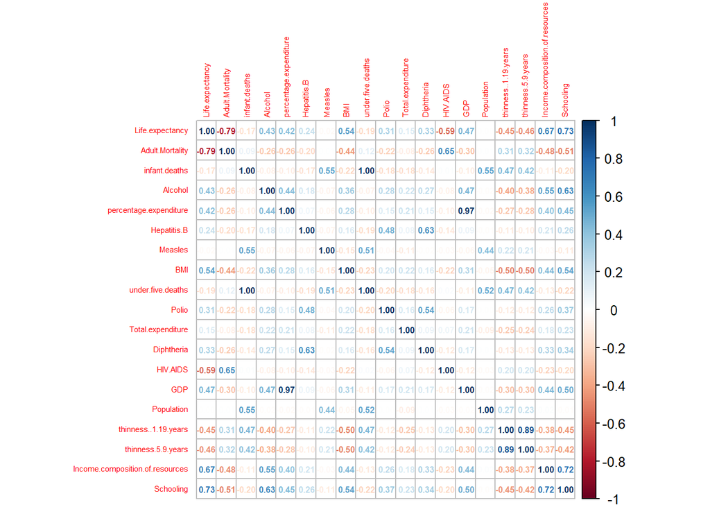

```r
library(corrplot)
correlations <- cor(newdata[,2:20])
corrplot(correlations, method = 'number', tl.cex = 0.47, addCoef.col ='black', number.cex = 0.49)
```

Poniżej ukazane zostały wykresy przedstawiające związki cech o najsilniejszej korelacji z cechą Life.expectancy. Adult.Mortality oraz HIV.AIDS wykazują silny związek ujemny, a Schooling i Income.composition.of.resources dodatni.

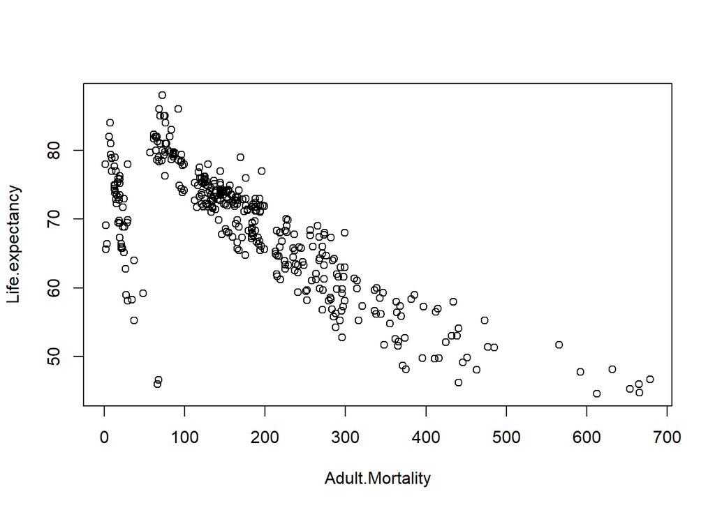

```r
plot(Adult.Mortality, Life.expectancy)
```

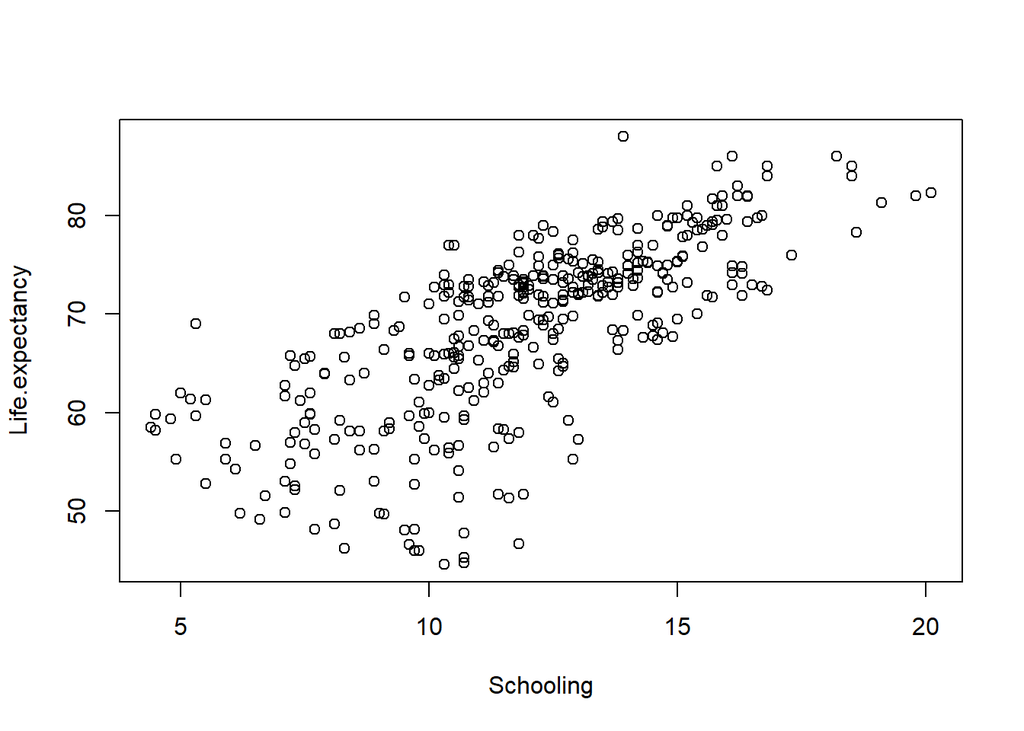

```r
plot(Schooling, Life.expectancy)
```

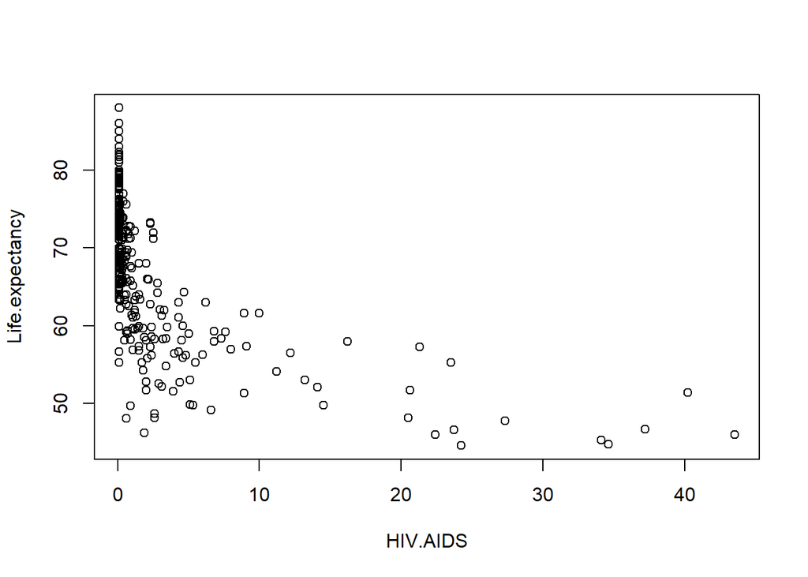

```r
plot(HIV.AIDS, Life.expectancy)
```

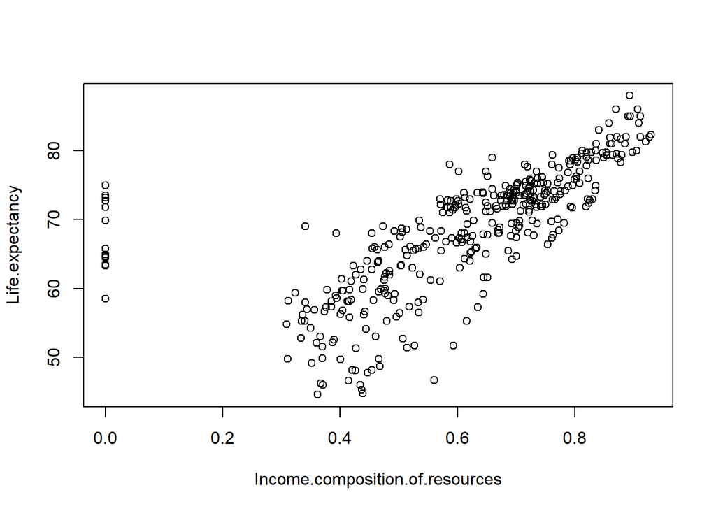

```r
plot(Income.composition.of.resources, Life.expectancy)
```

## Metody regresji

### Regresja liniowa

Najpierw przyjrzyjmy się pojedynczemu modelowi regresji (związek między Life.expectancy a Adult.Mortality).

```r
reg <- lm(Life.expectancy ~ Adult.Mortality, data = train)
```

```r
coef(reg)
```

```
##     (Intercept) Adult.Mortality
##     78.38450576     -0.05452958
```

```r
summary(reg)
```

```
##
## Call:
## lm(formula = Life.expectancy ~ Adult.Mortality, data = train)
##
## Residuals:
##      Min       1Q   Median       3Q      Max
## -28.7856  -2.4438   0.8049   3.6859  10.7052
##
## Coefficients:
##                  Estimate Std. Error t value Pr(>|t|)
## (Intercept)     78.384506   0.541781  144.68   <2e-16 ***
## Adult.Mortality -0.054530   0.002416  -22.57   <2e-16 ***
## ---
## Signif. codes:  0 '***' 0.001 '**' 0.01 '*' 0.05 '.' 0.1 ' ' 1
##
## Residual standard error: 5.407 on 307 degrees of freedom
## Multiple R-squared:  0.624,  Adjusted R-squared:  0.6228
## F-statistic: 509.6 on 1 and 307 DF,  p-value: < 2.2e-16
```

Obliczanie przedziałów ufności dla współczynników regresji:

```r
confint(reg)
```

```
##                       2.5 %      97.5 %
## (Intercept)     77.31843139 79.45058013
## Adult.Mortality -0.05928282 -0.04977633
```

Obliczanie przedziałów ufności dla predykcji:

```r
head(predict(reg, data.frame(Life.expectancy = c(5, 10, 15)), interval = "confidence"))
```

```
##        fit      lwr      upr
## 1 63.77058 63.04711 64.49405
## 2 61.15316 60.28351 62.02281
## 3 62.29828 61.49728 63.09928
## 4 72.98608 72.25668 73.71548
## 5 77.56656 76.55837 78.57476
## 6 77.40297 76.40615 78.39980
```

```r
head(predict(reg, data.frame(Life.expectancy = c(5, 10, 15)), interval = "prediction"))
```

```
##        fit      lwr      upr
## 1 63.77058 53.10613 74.43503
## 2 61.15316 50.47780 71.82852
## 3 62.29828 51.62830 72.96827
## 4 72.98608 62.32123 83.65093
## 5 77.56656 66.87903 88.25410
## 6 77.40297 66.71650 88.08944
```

Wykres regresji liniowej:

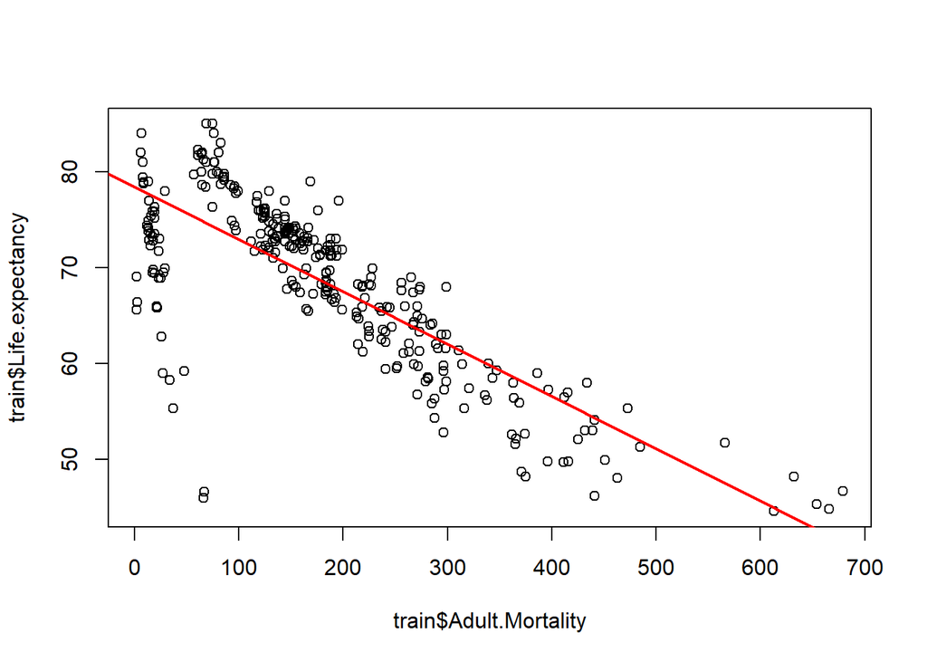

```r
plot(train$Adult.Mortality, train$Life.expectancy)
abline(reg, col = "red", lwd = 2)
```

Związek pomiędzy śmiertelnością u osób dorosłych a oczekiwaną długością życia jest ujemny.

Wykres przewidywanych wartości vs rzeczywistych (Life.expectancy):

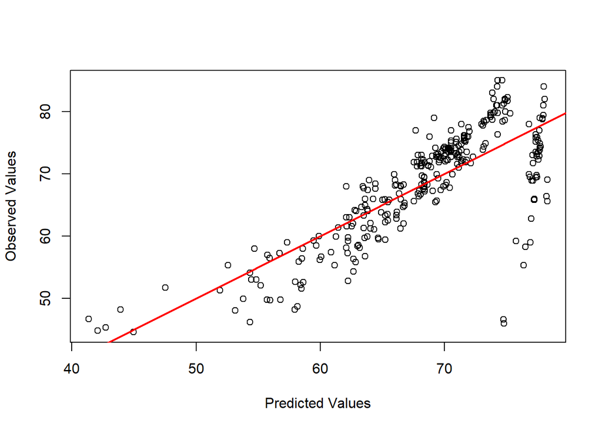

```r
plot(predict(reg),
     train$Life.expectancy,
     xlab = "Predicted Values",
     ylab = "Observed Values")
abline(a = 0,
       b = 1,
       col = "red",
       lwd = 2)
```

Można zaobserwować poprawność modelu, chociaż wiele przewidywanych wartości odbiega od wartości rzeczywistych.

Identyfikacja obserwacji wpływowych (statystyka leverage):

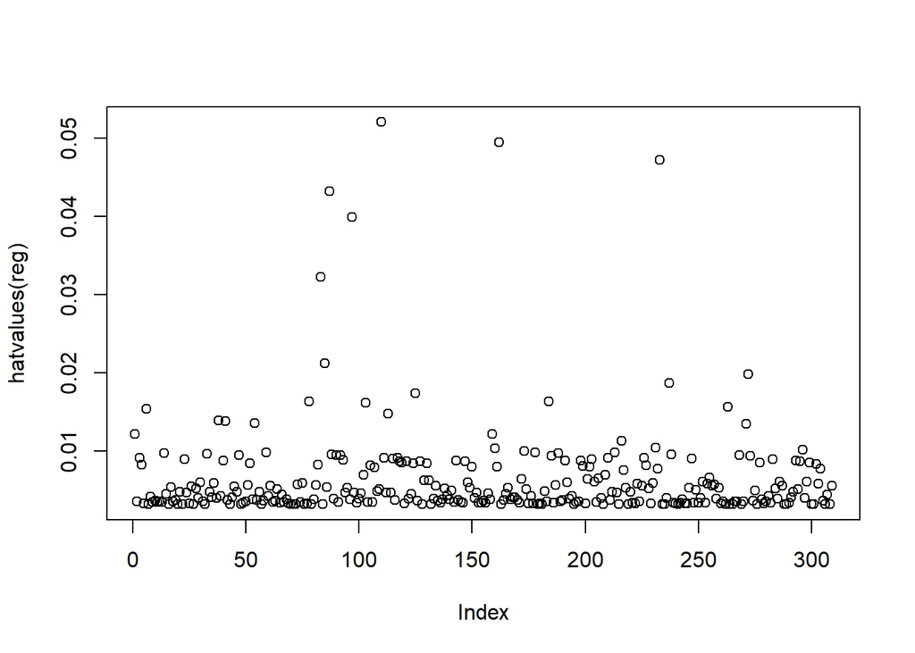

```r
plot(hatvalues(reg))
```

```r
which.max(hatvalues(reg))
```

```
##  49
## 110
```

### Regresja wielokrotna

W następnym modelu wykorzystamy wszystkie predyktory, aby móc ustalić, które najistotniej przyczyniają się do wyjaśnienia wariancji danych.

```r
reg_all <- lm(Life.expectancy ~ . -age_group, data = train)
summary(reg_all)
```

```
##
## Call:
## lm(formula = Life.expectancy ~ . - age_group, data = train)
##
## Residuals:
##      Min       1Q   Median       3Q      Max
## -11.2936  -2.0857   0.1362   2.2274  11.2403
##
## Coefficients:
##                                   Estimate Std. Error t value Pr(>|t|)
## (Intercept)                      5.769e+01  2.146e+00  26.879  < 2e-16 ***
## StatusDeveloping                -1.004e+00  8.630e-01  -1.163   0.2457
## Adult.Mortality                 -1.903e-02  2.718e-03  -7.000 1.79e-11 ***
## infant.deaths                    6.543e-02  2.976e-02   2.198   0.0287 *
## Alcohol                         -9.288e-02  8.083e-02  -1.149   0.2514
## percentage.expenditure          -2.379e-04  5.710e-04  -0.417   0.6773
## Hepatitis.B                     -1.680e-02  1.196e-02  -1.405   0.1611
## Measles                          1.835e-05  3.353e-05   0.547   0.5847
## BMI                              3.065e-02  1.437e-02   2.133   0.0338 *
## under.five.deaths               -4.812e-02  2.047e-02  -2.351   0.0194 *
## Polio                            1.612e-02  1.218e-02   1.324   0.1865
## Total.expenditure               -3.953e-02  1.065e-01  -0.371   0.7108
## Diphtheria                       1.021e-02  1.425e-02   0.716   0.4744
## HIV.AIDS                        -4.780e-01  5.574e-02  -8.574 6.14e-16 ***
## GDP                              9.829e-05  8.902e-05   1.104   0.2704
## Population                      -3.416e-09  3.849e-09  -0.887   0.3756
## thinness..1.19.years             2.398e-02  1.003e-01   0.239   0.8112
## thinness.5.9.years              -1.200e-01  9.842e-02  -1.220   0.2236
## Income.composition.of.resources  7.060e+00  1.711e+00   4.127 4.82e-05 ***
## Schooling                        8.909e-01  1.399e-01   6.369 7.45e-10 ***
## ---
## Signif. codes:  0 '***' 0.001 '**' 0.01 '*' 0.05 '.' 0.1 ' ' 1
##
## Residual standard error: 3.753 on 289 degrees of freedom
## Multiple R-squared:  0.8295, Adjusted R-squared:  0.8183
## F-statistic: 74.02 on 19 and 289 DF,  p-value: < 2.2e-16
```

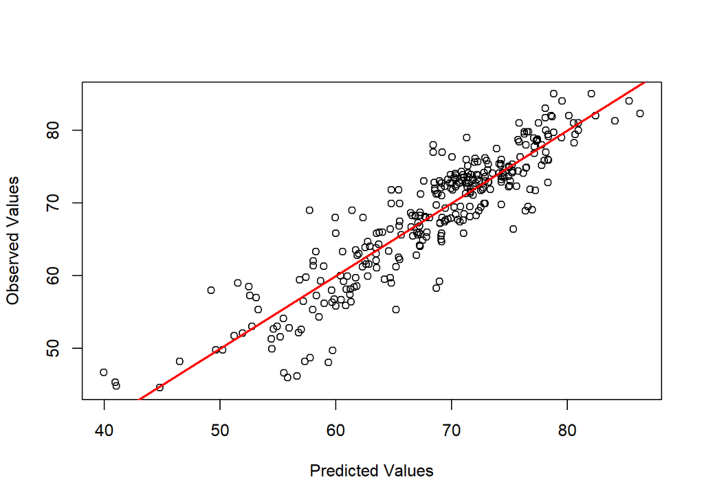

```r
plot(predict(reg_all),
     train$Life.expectancy,
     xlab = "Predicted Values",
     ylab = "Observed Values")
abline(a = 0,
       b = 1,
       col = "red",
       lwd = 2)
```

W powyższym modelu wykorzystano wszystkie możliwe parametry. Jak widać wartość Multiple R-Squared oraz Adjusted R-Squared jest wyższa w tym modelu niż w takim, gdzie jako predyktor użyto tylko Adult.Mortality. Jest to zatem model, który lepiej dopasowuje się do danych.

Z powyższego podsumowania wynika, że najbardziej znacżacymi zmiennymi jest Adult.Mortality (tak jak przewidywano), HIV.AIDS, Income.composition.of.resources oraz Schooling.

Stworzymy model, w którym zawarte zostaną tylko te zmienne.

```r
reg_multi<-lm(Life.expectancy ~ Adult.Mortality + HIV.AIDS + Income.composition.of.resources + Schooling, data = train)
summary(reg_multi)
```

```
##
## Call:
## lm(formula = Life.expectancy ~ Adult.Mortality + HIV.AIDS + Income.composition.of.resources +
##     Schooling, data = train)
##
## Residuals:
##      Min       1Q   Median       3Q      Max
## -11.5376  -2.2975   0.2642   2.6300  10.3026
##
## Coefficients:
##                                  Estimate Std. Error t value Pr(>|t|)
## (Intercept)                     55.673907   1.427802  38.993  < 2e-16 ***
## Adult.Mortality                 -0.022958   0.002673  -8.589 4.65e-16 ***
## HIV.AIDS                        -0.478669   0.056522  -8.469 1.08e-15 ***
## Income.composition.of.resources  8.138361   1.670591   4.872 1.78e-06 ***
## Schooling                        1.084313   0.119058   9.107  < 2e-16 ***
## ---
## Signif. codes:  0 '***' 0.001 '**' 0.01 '*' 0.05 '.' 0.1 ' ' 1
##
## Residual standard error: 3.873 on 304 degrees of freedom
## Multiple R-squared:  0.8091, Adjusted R-squared:  0.8065
## F-statistic:   322 on 4 and 304 DF,  p-value: < 2.2e-16
```

Wykres przewidywanych wartości vs rzeczywistych wartości.

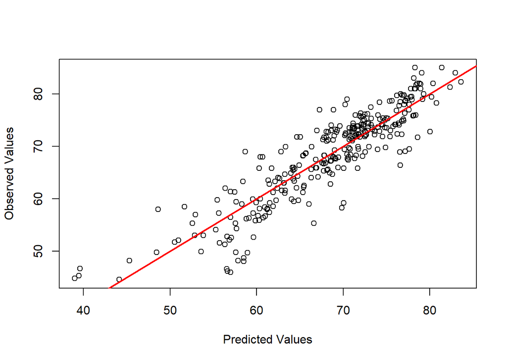

```r
plot(predict(reg_multi),
     train$Life.expectancy,
     xlab = "Predicted Values",
     ylab = "Observed Values")
abline(a = 0,
       b = 1,
       col = "red",
       lwd = 2)
```

Jak widać, ten model zapewnił większą zbieżność wyników niż w przypadku użycia tylko zmiennej Adult.Mortality. W porównaniu do modelu, gdzie użyto wszystkich predyktorów, Residual Standard Error jest większy, a R-Squared mniejszy. Oznacza to, że dopasowanie modelu z wybranymi predyktorami jest nieznacznie gorsze.

```r
reg_multipred <- predict(reg_multi, newdata = test)
rmse <- sqrt(sum((exp(reg_multipred) - test$Life.expectancy)^2)/length(test$Life.expectancy))
c(RMSE = rmse, R2=summary(reg_multi)$r.squared)
```

```
##         RMSE           R2
## 1.543258e+35 8.090529e-01
```

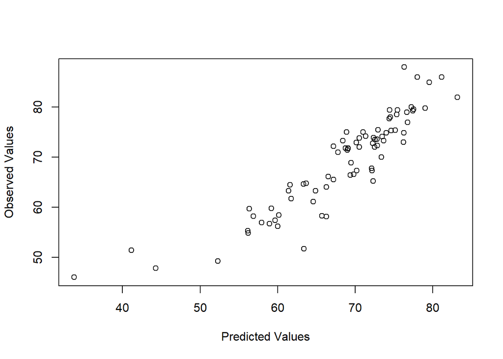

```r
plot(reg_multipred, test$Life.expectancy, xlab = "Predicted Values", ylab = "Observed Values")
```

## Metody klsyfikacji

### Regresja logistyczna

```r
log <- list()
log$model <- nnet::multinom(age_group ~. -Life.expectancy, data = train)
summary(log$model)
```

```
## Call:
## nnet::multinom(formula = age_group ~ . - Life.expectancy, data = train)
##
## Coefficients:
##       (Intercept) StatusDeveloping Adult.Mortality infant.deaths    Alcohol
## 50-65  -9.9454960        13.320244     -0.01271677    -0.2649832 -0.2204291
## 65-80   0.2920923         3.204726     -0.02815033    -0.2087407 -0.2688503
## 80+   -57.8405382         5.491691     -0.03005338    -0.4368438 -0.7801173
##       percentage.expenditure Hepatitis.B      Measles        BMI
## 50-65             0.01413451 -0.02040528 0.0007806078 0.01313723
## 65-80             0.01626592 -0.01468993 0.0007603187 0.04707630
## 80+               0.01709966  0.01294874 0.0014783540 0.02115668
##       under.five.deaths      Polio Total.expenditure   Diphtheria  HIV.AIDS
## 50-65         0.1609742 0.03493593        -0.4369379  0.002626810 -0.361339
## 65-80         0.1284236 0.02919289        -0.4450760 -0.005041737 -1.916137
## 80+           0.1530004 0.02568782        -1.2048294 -0.048255081  1.250626
##                 GDP   Population thinness..1.19.years thinness.5.9.years
## 50-65 -0.0012547493 1.656999e-07           -0.3969319          0.2000039
## 65-80 -0.0008793857 1.692186e-07           -0.3907295          0.2183193
## 80+   -0.0009657380 2.389907e-07           -2.7845904         -1.5345883
##       Income.composition.of.resources Schooling
## 50-65                        1.649840 0.8206615
## 65-80                        6.824175 0.9455913
## 80+                         94.862677 0.8009828
##
## Std. Errors:
##        (Intercept) StatusDeveloping Adult.Mortality infant.deaths      Alcohol
## 50-65 6.563245e-10     6.563245e-10    1.786193e-07  5.516654e-08 1.301313e-09
## 65-80 7.544593e-10     7.180541e-10    1.560141e-07  7.158689e-08 3.081676e-09
## 80+   2.935799e-10     1.774019e-10    1.998636e-08  4.302320e-08 2.865311e-09
##       percentage.expenditure  Hepatitis.B      Measles          BMI
## 50-65           2.906916e-08 4.513844e-08 1.626437e-05 1.073125e-08
## 65-80           1.633111e-06 5.763288e-08 3.200893e-05 1.863636e-08
## 80+             1.622843e-06 2.490501e-08 1.639089e-05 1.390821e-08
##       under.five.deaths        Polio Total.expenditure   Diphtheria
## 50-65      8.205669e-08 4.192091e-08      3.621404e-09 4.457808e-08
## 65-80      8.920317e-08 5.803771e-08      4.332232e-09 5.853251e-08
## 80+        5.012910e-08 2.776429e-08      2.290152e-09 2.770972e-08
##           HIV.AIDS          GDP   Population thinness..1.19.years
## 50-65 8.616739e-10 3.741815e-07 4.345583e-08         4.234003e-09
## 65-80 2.355616e-10 1.062630e-05 4.496362e-08         4.457228e-09
## 80+   3.303865e-11 1.050242e-05 4.957740e-08         7.320264e-10
##       thinness.5.9.years Income.composition.of.resources    Schooling
## 50-65       4.670106e-09                    3.020361e-10 5.632249e-09
## 65-80       4.366798e-09                    4.246783e-10 7.750109e-09
## 80+         6.517022e-10                    2.457268e-10 4.481197e-09
##
## Residual Deviance: 137.7521
## AIC: 257.7521
```

Po stworzeniu modelu sprawdzimy, jakie klasy przewiduje.

```r
log$pred <- predict(log$model, newdata = train, "class")
log$tabtrain <-table(Actual = train$age_group, Predicted = log$pred)
log$tabtrain
```

```
##        Predicted
## Actual  35-50 50-65 65-80 80+
##   35-50     9     6     0   0
##   50-65     2    67     9   0
##   65-80     0     8   192   0
##   80+       0     0     2  14
```

Macierz pomyłek pokazuje, że na zbiorze uczącym 27 przypadków zostało sklasyfikowanych nieprawidłowo na 309. To daje skuteczność modelu dla poszczególnych klas oraz dla całego modelu:

```r
(sum(diag(log$tabtrain))/sum(log$tabtrain))*100
```

```
## [1] 91.26214
```

Skuteczność wyniosła 91.26 %, co jest bardzo wysokim wynikiem. Aby sprawdzić rzeczywistą skuteczność modelu należy zweryfikować predykcje na zbiorze testowym.

```r
log$testpred <- predict(log$model, newdata = test, "class")
log$tabtest <-table(Actual = test$age_group, Predicted = log$testpred)
log$tabtest
```

```
##        Predicted
## Actual  35-50 50-65 65-80 80+
##   35-50     3     0     0   0
##   50-65     2    15     4   1
##   65-80     1     0    43   4
##   80+       0     0     0   5
```

```r
log$acc <- (sum(diag(log$tabtest))/sum(log$tabtest))*100
log$acc
```

```
## [1] 84.61538
```

Weryfikacja predykcji na zbiorze testowym dała skuteczność 84.62%. Jak widać model osiąga całkiem dobrą skuteczność także na danych, których nie widział wcześniej.

Czy jest możliwość, aby poprawić skuteczność modelu? Spróbujmy wyeliminować najsłabsze predyktory.

```r
cor(newdata[2:20], newdata$Life.expectancy)
```

```
##                                         [,1]
## Life.expectancy                  1.000000000
## Adult.Mortality                 -0.787842158
## infant.deaths                   -0.165456217
## Alcohol                          0.429199434
## percentage.expenditure           0.421971100
## Hepatitis.B                      0.236663157
## Measles                         -0.024926246
## BMI                              0.544165484
## under.five.deaths               -0.194428073
## Polio                            0.310557774
## Total.expenditure                0.147948362
## Diphtheria                       0.331422157
## HIV.AIDS                        -0.589324724
## GDP                              0.467466345
## Population                      -0.002114907
## thinness..1.19.years            -0.453389476
## thinness.5.9.years              -0.460444010
## Income.composition.of.resources  0.673900828
## Schooling                        0.725886069
```

Po zobrazowaniu korelacji między zmienną Life.expectancy a wszystkimi zmiennymi, można wnioskować, że najmniej do modelu przyczynią się predyktory Measles, infant.deaths, under.five.deaths, Total.expenditure oraz Population.

```r
log$model2 <- nnet::multinom(age_group ~ . - (Life.expectancy + Measles + infant.deaths + under.five.deaths + Total.expenditure + Population), data = train)
summary(log$model2)
```

```
## Call:
## nnet::multinom(formula = age_group ~ . - (Life.expectancy + Measles +
##     infant.deaths + under.five.deaths + Total.expenditure + Population),
##     data = train)
##
## Coefficients:
##       (Intercept) StatusDeveloping Adult.Mortality    Alcohol
## 50-65  -5.1536044         8.198755    -0.006683831 -0.0943546
## 65-80   0.9001015         3.167174    -0.022599961 -0.1321032
## 80+   -55.3353583         5.435965    -0.046483851 -0.3687908
##       percentage.expenditure Hepatitis.B         BMI        Polio   Diphtheria
## 50-65             0.01619689 0.006214208 -0.02445005 -0.002336945 -0.007548082
## 65-80             0.01606605 0.007396247  0.00404494 -0.013012041 -0.015621636
## 80+               0.01657106 0.045993071 -0.02420995 -0.041630315 -0.115948305
##         HIV.AIDS           GDP thinness..1.19.years thinness.5.9.years
## 50-65 -0.1682723 -0.0011359533           -0.1746766         0.04997591
## 65-80 -1.6832338 -0.0005390411           -0.1277311         0.04858087
## 80+    0.5173454 -0.0006207313           -1.0239193        -1.98348546
##       Income.composition.of.resources Schooling
## 50-65                        1.375553 0.3777734
## 65-80                        7.061414 0.5007371
## 80+                         82.069804 0.9362672
##
## Std. Errors:
##        (Intercept) StatusDeveloping Adult.Mortality    Alcohol
## 50-65 0.0035294828      0.003529773     0.002761204 0.06820489
## 65-80 0.0038545997      0.003035159     0.004588389 0.04694514
## 80+   0.0009543515      0.001139258     0.018613955 0.01134486
##       percentage.expenditure Hepatitis.B        BMI      Polio Diphtheria
## 50-65            0.008404571  0.02184084 0.04485233 0.01958797 0.01745091
## 65-80            0.006258913  0.02741260 0.04867555 0.02504953 0.02481889
## 80+              0.006371983  0.03583413 0.05409021 0.06672416 0.06941519
##           HIV.AIDS          GDP thinness..1.19.years thinness.5.9.years
## 50-65 5.221945e-02 0.0005743882          0.061859059        0.062951121
## 65-80 5.612693e-03 0.0002658064          0.066857377        0.072112776
## 80+   9.538025e-05 0.0003241289          0.002570475        0.002667723
##       Income.composition.of.resources  Schooling
## 50-65                    0.0017633301 0.07369680
## 65-80                    0.0019618136 0.07785284
## 80+                      0.0007069049 0.01352284
##
## Residual Deviance: 158.4232
## AIC: 248.4232
```

```r
log$pred2 <- predict(log$model, newdata = train, "class")
log$tabtrain2 <-table(Actual = train$age_group, Predicted = log$pred2)
log$tabtrain2
```

```
##        Predicted
## Actual  35-50 50-65 65-80 80+
##   35-50     9     6     0   0
##   50-65     2    67     9   0
##   65-80     0     8   192   0
##   80+       0     0     2  14
```

```r
(sum(diag(log$tabtrain2))/sum(log$tabtrain2))*100
```

```
## [1] 91.26214
```

```r
log$testpred2 <- predict(log$model2, newdata = test, "class")
log$tabtest2 <-table(Actual = test$age_group, Predicted = log$testpred2)
log$tabtest2
```

```
##        Predicted
## Actual  35-50 50-65 65-80 80+
##   35-50     2     1     0   0
##   50-65     1    17     4   0
##   65-80     0     0    46   2
##   80+       0     0     2   3
```

```r
log$acc2 <- (sum(diag(log$tabtest2))/sum(log$tabtest2))*100
log$acc2
```

```
## [1] 87.17949
```

Na nowo poznanych danych ze zbioru testowego model osiągnął skuteczność 87.18 %. Usunięcie zbędnych predyktorów podczas definiowania modelu przyczyniło się do poprawy jego skuteczności.

### LDA - Liniowa Analiza Dyskryminacyjna

```r
library(MASS)
lda <- list()
lda$model <- lda(age_group ~ . - (Life.expectancy + age_group), data = train)
lda$model
```

```
## Call:
## lda(age_group ~ . - (Life.expectancy + age_group), data = train)
##
## Prior probabilities of groups:
##      35-50      50-65      65-80        80+
## 0.04854369 0.25242718 0.64724919 0.05177994
##
## Group means:
##       StatusDeveloping Adult.Mortality infant.deaths  Alcohol
## 35-50             1.00        446.7333      70.20000 3.242000
## 50-65             1.00        294.0897      42.61538 2.592308
## 65-80             0.84        132.3300      31.42000 4.819850
## 80+               0.50         59.0000       1.25000 8.800000
##       percentage.expenditure Hepatitis.B   Measles      BMI under.five.deaths
## 35-50               73.76015    68.46667  805.8667 19.48667         110.13333
## 50-65              114.85824    71.64103 1670.6923 21.31795          65.55128
## 65-80              524.38697    82.48500 2716.9000 39.86250          40.01000
## 80+               4261.49600    80.93750  440.0000 51.72500           1.31250
##          Polio Total.expenditure Diphtheria  HIV.AIDS        GDP Population
## 35-50 75.66667          5.958000   67.73333 15.346667   917.1805    5661185
## 50-65 71.87179          6.052308   72.69231  4.180769  1058.4377   10180672
## 65-80 86.75500          5.801650   87.20000  0.277000  5014.1535   20720437
## 80+   94.37500          7.939375   94.37500  0.100000 28420.9726   15644822
##       thinness..1.19.years thinness.5.9.years Income.composition.of.resources
## 35-50             8.640000           8.593333                       0.4178000
## 50-65             6.853846           6.865385                       0.4388333
## 65-80             4.546000           4.556000                       0.6664100
## 80+               0.706250           0.662500                       0.8812500
##       Schooling
## 35-50  9.166667
## 50-65  9.319231
## 65-80 12.693500
## 80+   16.768750
##
## Coefficients of linear discriminants:
##                                           LD1           LD2           LD3
## StatusDeveloping                 1.739385e-01  3.150254e-01  4.836798e-01
## Adult.Mortality                 -4.754058e-03  1.512898e-03  2.088393e-03
## infant.deaths                    2.968981e-02 -2.388931e-02 -1.613188e-02
## Alcohol                         -6.097349e-02 -4.636239e-02  3.222212e-02
## percentage.expenditure           1.987322e-04  9.810658e-04  5.526655e-04
## Hepatitis.B                      9.265876e-04 -4.885187e-03 -7.032564e-04
## Measles                         -1.213490e-05  6.307131e-06  1.413670e-05
## BMI                              6.559614e-03 -3.372045e-03 -1.782855e-02
## under.five.deaths               -2.026159e-02  1.738289e-02  9.142858e-03
## Polio                            4.199655e-03  2.545102e-03 -1.127634e-02
## Total.expenditure               -8.905474e-02  4.111839e-02  1.314863e-01
## Diphtheria                      -1.826657e-03  3.573598e-03  3.348234e-03
## HIV.AIDS                        -1.156634e-01  7.968623e-02 -1.939075e-01
## GDP                             -9.790257e-06 -2.044649e-05 -3.903385e-05
## Population                      -5.942216e-10  1.181706e-09  2.291761e-09
## thinness..1.19.years            -2.580299e-02  7.072730e-03  2.562080e-03
## thinness.5.9.years              -1.137158e-03 -2.824533e-02 -1.941368e-02
## Income.composition.of.resources  2.285107e+00 -6.843771e-02 -1.788484e+00
## Schooling                        2.153070e-01  6.440437e-02 -8.000215e-02
##
## Proportion of trace:
##    LD1    LD2    LD3
## 0.7778 0.1686 0.0536
```

```r
lda$pred <- predict(lda$model, newdata = train)
lda$tabtrain <- table(Actual = train$age_group, Predicted = lda$pred$class)
lda$tabtrain
```

```
##        Predicted
## Actual  35-50 50-65 65-80 80+
##   35-50     9     6     0   0
##   50-65     7    55    16   0
##   65-80     0    10   186   4
##   80+       0     0     8   8
```

```r
(sum(diag(lda$tabtrain))/sum(lda$tabtrain))*100
```

```
## [1] 83.49515
```

Skuteczność modelu na danych treningowych wyniosła 83.5%.

```r
lda$testpred <- predict(lda$model, newdata = test)
lda$tabtest <- table(Actual = test$age_group, Predicted = lda$testpred$class)
lda$tabtest
```

```
##        Predicted
## Actual  35-50 50-65 65-80 80+
##   35-50     2     1     0   0
##   50-65     1    16     5   0
##   65-80     0     1    45   2
##   80+       0     0     1   4
```

```r
lda$acc <- (sum(diag(lda$tabtest))/sum(lda$tabtest))*100
lda$acc
```

```
## [1] 85.89744
```

Model osiągnął lepszy wynik w klasyfikacji na danych testowych. Sprawdźmy, czy skuteczność modelu wzrośnie po usunięciu zbędnych predyktorów z poprzedniego modelu.

```r
lda$model2 <- lda(age_group ~ . - (Life.expectancy + age_group + Measles + infant.deaths + under.five.deaths + Total.expenditure + Population), data = train)
lda$model2
```

```
## Call:
## lda(age_group ~ . - (Life.expectancy + age_group + Measles +
##     infant.deaths + under.five.deaths + Total.expenditure + Population),
##     data = train)
##
## Prior probabilities of groups:
##      35-50      50-65      65-80        80+
## 0.04854369 0.25242718 0.64724919 0.05177994
##
## Group means:
##       StatusDeveloping Adult.Mortality  Alcohol percentage.expenditure
## 35-50             1.00        446.7333 3.242000               73.76015
## 50-65             1.00        294.0897 2.592308              114.85824
## 65-80             0.84        132.3300 4.819850              524.38697
## 80+               0.50         59.0000 8.800000             4261.49600
##       Hepatitis.B      BMI    Polio Diphtheria  HIV.AIDS        GDP
## 35-50    68.46667 19.48667 75.66667   67.73333 15.346667   917.1805
## 50-65    71.64103 21.31795 71.87179   72.69231  4.180769  1058.4377
## 65-80    82.48500 39.86250 86.75500   87.20000  0.277000  5014.1535
## 80+      80.93750 51.72500 94.37500   94.37500  0.100000 28420.9726
##       thinness..1.19.years thinness.5.9.years Income.composition.of.resources
## 35-50             8.640000           8.593333                       0.4178000
## 50-65             6.853846           6.865385                       0.4388333
## 65-80             4.546000           4.556000                       0.6664100
## 80+               0.706250           0.662500                       0.8812500
##       Schooling
## 35-50  9.166667
## 50-65  9.319231
## 65-80 12.693500
## 80+   16.768750
##
## Coefficients of linear discriminants:
##                                           LD1           LD2           LD3
## StatusDeveloping                 1.849980e-01  3.424060e-01  4.755957e-01
## Adult.Mortality                 -4.917897e-03  2.034039e-03  2.499764e-03
## Alcohol                         -7.656968e-02 -2.181493e-02  3.390294e-02
## percentage.expenditure           1.602488e-04  1.005814e-03  7.256637e-04
## Hepatitis.B                     -1.509622e-04 -4.801053e-03  7.006208e-04
## BMI                              5.487333e-03 -2.931985e-03 -1.780312e-02
## Polio                            4.522481e-03  5.673869e-04 -9.436832e-03
## Diphtheria                      -6.246066e-04  2.494125e-03  3.212783e-03
## HIV.AIDS                        -1.202914e-01  8.624936e-02 -1.868949e-01
## GDP                             -3.735475e-06 -2.187433e-05 -5.392151e-05
## thinness..1.19.years             5.985947e-03  2.355458e-03 -3.610445e-02
## thinness.5.9.years              -7.597669e-03 -2.137187e-02 -1.888220e-02
## Income.composition.of.resources  2.413031e+00 -1.849460e-01 -2.122963e+00
## Schooling                        2.171875e-01  4.896933e-02 -7.959958e-02
##
## Proportion of trace:
##    LD1    LD2    LD3
## 0.7734 0.1755 0.0511
```

```r
lda$pred2 <- predict(lda$model2, newdata = train)
lda$tabtrain2 <- table(Actual = train$age_group, Predicted = lda$pred2$class)
lda$tabtrain2
```

```
##        Predicted
## Actual  35-50 50-65 65-80 80+
##   35-50     8     7     0   0
##   50-65     6    58    14   0
##   65-80     0    10   185   5
##   80+       0     0     8   8
```

```r
(sum(diag(lda$tabtrain2))/sum(lda$tabtrain2))*100
```

```
## [1] 83.81877
```

```r
lda$testpred2 <- predict(lda$model2, newdata = test)
lda$tabtest2 <- table(Actual = test$age_group, Predicted = lda$testpred2$class)
lda$tabtest2
```

```
##        Predicted
## Actual  35-50 50-65 65-80 80+
##   35-50     2     1     0   0
##   50-65     1    17     4   0
##   65-80     0     0    46   2
##   80+       0     0     1   4
```

```r
lda$acc2 <- (sum(diag(lda$tabtest2))/sum(lda$tabtest2))*100
lda$acc2
```

```
## [1] 88.46154
```

Usunięcie zbędnych predyktorów z modelu wpłynęło na wzrost skuteczności modelu (wzrost skuteczności o 3% na danych testowych).

### Metoda kNN

```r
knn <- list()
knn$drop <-c("Life.expectancy", "Status")
knn$dataset = newdata[,!(names(newdata) %in% knn$drop)]
dim(knn$dataset)
```

```
## [1] 387  19
```

```r
set.seed(1)
library(class)
row.number <- sample(1:nrow(knn$dataset), 0.8*nrow(knn$dataset))
knn$train <- knn$dataset[row.number,1:18]
knn$test <- knn$dataset[-row.number,1:18]
dim(knn$train)
```

```
## [1] 309  18
```

```r
dim(knn$test)
```

```
## [1] 78 18
```

```r
age_group_train <- knn$dataset[row.number,19]
age_group_test <- knn$dataset[-row.number,19]
knn$pred1 <- knn(train = knn$train, test = knn$test,cl = age_group_train, k = 1)
knn$tab1 <-table(Actual = age_group_test, Predicted = knn$pred1)
knn$tab1
```

```
##        Predicted
## Actual  35-50 50-65 65-80 80+
##   35-50     1     1     1   0
##   50-65     3     6    13   0
##   65-80     3    14    29   2
##   80+       0     0     4   1
```

```r
knn$acc1 <- (sum(diag(knn$tab1))/sum(knn$tab1))*100
knn$acc1
```

```
## [1] 47.4359
```

```r
knn$pred3 <- knn(train = knn$train, test = knn$test,cl = age_group_train, k = 3)
knn$tab3 <-table(Actual = age_group_test, Predicted = knn$pred3)
knn$tab3
```

```
##        Predicted
## Actual  35-50 50-65 65-80 80+
##   35-50     0     1     2   0
##   50-65     1     6    15   0
##   65-80     4     4    40   0
##   80+       0     1     4   0
```

```r
knn$acc3 <- (sum(diag(knn$tab3))/sum(knn$tab3))*100
knn$acc3
```

```
## [1] 58.97436
```

```r
knn$pred5 <- knn(train = knn$train, test = knn$test,cl = age_group_train, k = 5)
knn$tab5 <-table(Actual = age_group_test, Predicted = knn$pred5)
knn$tab5
```

```
##        Predicted
## Actual  35-50 50-65 65-80 80+
##   35-50     0     1     2   0
##   50-65     1     4    17   0
##   65-80     1     4    43   0
##   80+       0     1     4   0
```

```r
knn$acc5 <- (sum(diag(knn$tab5))/sum(knn$tab5))*100
knn$acc5
```

```
## [1] 60.25641
```

```r
knn$pred7 <- knn(train = knn$train, test = knn$test,cl = age_group_train, k = 7)
knn$tab7 <-table(Actual = age_group_test, Predicted = knn$pred7)
knn$tab7
```

```
##        Predicted
## Actual  35-50 50-65 65-80 80+
##   35-50     1     0     2   0
##   50-65     1     5    16   0
##   65-80     0     1    47   0
##   80+       0     0     5   0
```

```r
knn$acc7 <- (sum(diag(knn$tab7))/sum(knn$tab7))*100
knn$acc7
```

```
## [1] 67.94872
```

```r
knn$pred10 <- knn(train = knn$train, test = knn$test,cl = age_group_train, k = 10)
knn$tab10 <-table(Actual = age_group_test, Predicted = knn$pred10)
knn$tab10
```

```
##        Predicted
## Actual  35-50 50-65 65-80 80+
##   35-50     0     0     3   0
##   50-65     0     4    18   0
##   65-80     0     4    44   0
##   80+       0     0     5   0
```

```r
knn$acc10 <- (sum(diag(knn$tab10))/sum(knn$tab10))*100
knn$acc10
```

```
## [1] 61.53846
```

Tabela przedstawiająca porównanie wyników poszczególnych metod klasyfikacji (skuteczność). Modele regresji logistyczna 2 oraz Lda 2 zostały stworzone dla zredukowanej liczby predyktorów, dla których korelacja z Life.expectancy wahała się w przedziale [-0.2,0.2]: Measles, infant.deaths, under.five.deaths, Total.expenditure oraz Population.

```r
tab <- matrix(c(log$acc, log$acc2, lda$acc, lda$acc2, 0, knn$acc1, knn$acc3, knn$acc5, knn$acc7, knn$acc10), ncol=1, byrow=TRUE)
colnames(tab) <- c("Skuteczność [%]")
rownames(tab) <- c('Regresja Logistyczna 1', 'Regresja Logistyczna 2', 'LDA 1', 'LDA 2', 'Qda', 'kNN, k = 1', 'kNN, k = 3', 'kNN, k = 5', 'kNN, k = 7','kNN, k = 10')
tab <- as.table(tab)
tab
```

```
##                        Skuteczność [%]
## Regresja Logistyczna 1        84.61538
## Regresja Logistyczna 2        87.17949
## LDA 1                         85.89744
## LDA 2                         88.46154
## Qda                            0.00000
## kNN, k = 1                    47.43590
## kNN, k = 3                    58.97436
## kNN, k = 5                    60.25641
## kNN, k = 7                    67.94872
## kNN, k = 10                   61.53846
```

Najlepsze wyniki uzyskały modele LDA 2 oraz Regresja Logistyczna 2, w których uwzględnione zostały tylko niezbędne predyktory. Dla metody kNN najlepszym parametrem była liczba 7 sąsiadów, gdyż dla większej liczby sąsiadów skuteczność zaczynała maleć.

## Selekcja cech

```r
newdata <-na.omit(newdata)
dim(newdata)
```

```
## [1] 387  21
```

Po usunięciu wierszy, które zawierają wartości NA można przystąpić do wyboru najlepszego podzbioru.

Zbiór zawiera 21 atrybutów, z czego Life.expectancy należy wskazać, a age_group wykluczamy (klasy do klasyfikacji), zatem używamy modeli o maksymalnej liczbie cech 19.

### Wybór najlepszego podzbioru

```r
library(leaps)
selection <- regsubsets(Life.expectancy ~. -age_group, data = newdata, nvmax = 19)
selection <- summary(selection)
selection
```

```
## Subset selection object
## Call: regsubsets.formula(Life.expectancy ~ . - age_group, data = newdata,
##     nvmax = 19)
## 19 Variables  (and intercept)
##                                 Forced in Forced out
## StatusDeveloping                    FALSE      FALSE
## Adult.Mortality                     FALSE      FALSE
## infant.deaths                       FALSE      FALSE
## Alcohol                             FALSE      FALSE
## percentage.expenditure              FALSE      FALSE
## Hepatitis.B                         FALSE      FALSE
## Measles                             FALSE      FALSE
## BMI                                 FALSE      FALSE
## under.five.deaths                   FALSE      FALSE
## Polio                               FALSE      FALSE
```

[output cut: 111 more lines]

Najczęściej użytym predyktorem w podzbiorach jest Adult.Mortality oraz Schooling, a predyktory thinness..1.19.years oraz Total.expenditure wykorzystano najmniej razy.

Sprawdżmy, które podzbiory są najlepsze według różnych kryteriów:

- miara Cp:

```r
selection$cp
```

```
##  [1] 476.706251 151.758638  80.614899  46.409952  32.906616  22.585331
##  [7]  19.395265  10.881477   8.972141   8.979165   8.687554   9.425396
## [13]  10.537425  11.475996  12.792079  14.163457  16.079346  18.005851
## [19]  20.000000
```

```r
selection$cpmin <- which.min(selection$cp)
selection$cpmin
```

```
## [1] 11
```

```r
selection$cp[selection$cpmin]
```

```
## [1] 8.687554
```

Według miary Cp najlepszym podzbiorem jest zbiór 11, gdzie użyte zostało 11 cech.

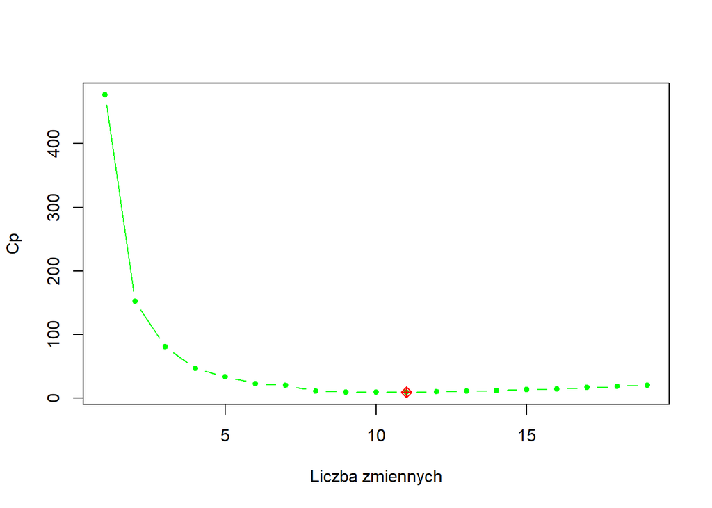

```r
plot(selection$cp, xlab = "Liczba zmiennych", ylab = "Cp", col = "green",
     type = "b", pch = 20)
points(selection$cpmin, selection$cp[selection$cpmin], col = "red", pch = 9)
```

- kryterium BIC:

```r
selection$cp
```

```
##  [1] 476.706251 151.758638  80.614899  46.409952  32.906616  22.585331
##  [7]  19.395265  10.881477   8.972141   8.979165   8.687554   9.425396
## [13]  10.537425  11.475996  12.792079  14.163457  16.079346  18.005851
## [19]  20.000000
```

```r
selection$bicmin <- which.min(selection$bic)
selection$bicmin
```

```
## [1] 8
```

```r
selection$bic[selection$bicmin]
```

```
## [1] -637.613
```

Według kryterium BIC, najlepszy wynik osiągnął podzbiór 8, w którym wykorzystano 8 cech.

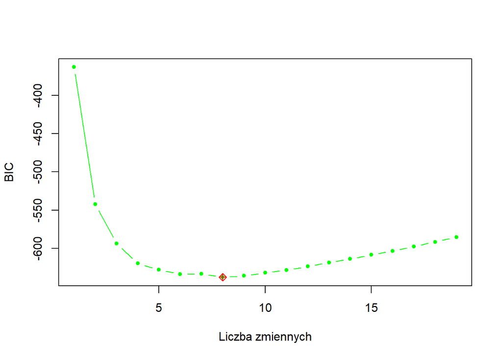

```r
plot(selection$bic, xlab = "Liczba zmiennych", ylab = "BIC", col = "green",
     type = "b", pch = 20)
points(selection$bicmin, selection$bic[selection$bicmin], col = "red", pch = 9)
```

- poprawione R^2:

```r
selection$adjr2
```

```
##  [1] 0.6197101 0.7637212 0.7956283 0.8112343 0.8176687 0.8227109 0.8245753
##  [8] 0.8288481 0.8301601 0.8306111 0.8312001 0.8313235 0.8312767 0.8313091
## [15] 0.8311683 0.8310014 0.8305822 0.8301558 0.8296958
```

```r
selection$adjr2min <- which.max(selection$adjr2)
selection$adjr2min
```

```
## [1] 12
```

```r
selection$adjr2[selection$adrj2min]
```

```
## numeric(0)
```

Największą wartość poprawionego R^2 uzyskał podzbiór 12 zawierający 12 cech.

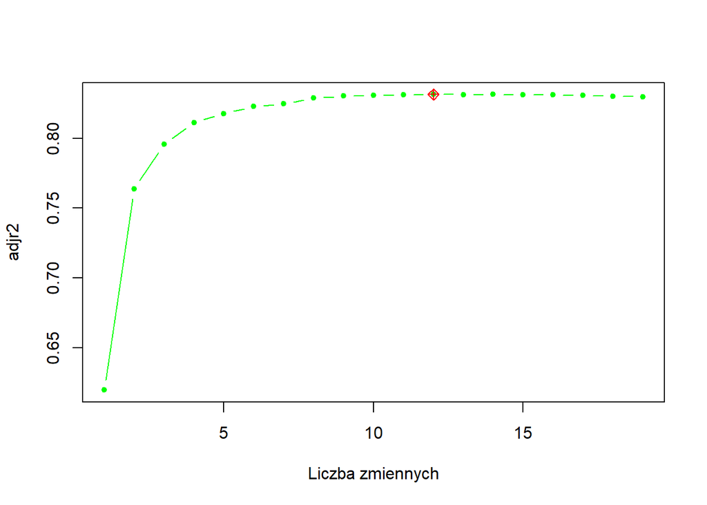

```r
plot(selection$adjr2, xlab = "Liczba zmiennych", ylab = "adjr2", col = "green",
     type = "b", pch = 20)
points(selection$adjr2min, selection$adjr2[selection$adjr2min], col = "red", pch = 9)
```

### Selekcja krokowa do przodu

```r
selection_fwd <- regsubsets(Life.expectancy ~. -age_group, data = newdata, nvmax = 19, method = "forward")
selection_fwd <- summary(selection_fwd)
selection_fwd
```

```
## Subset selection object
## Call: regsubsets.formula(Life.expectancy ~ . - age_group, data = newdata,
##     nvmax = 19, method = "forward")
## 19 Variables  (and intercept)
##                                 Forced in Forced out
## StatusDeveloping                    FALSE      FALSE
## Adult.Mortality                     FALSE      FALSE
## infant.deaths                       FALSE      FALSE
## Alcohol                             FALSE      FALSE
## percentage.expenditure              FALSE      FALSE
## Hepatitis.B                         FALSE      FALSE
## Measles                             FALSE      FALSE
## BMI                                 FALSE      FALSE
## under.five.deaths                   FALSE      FALSE
## Polio                               FALSE      FALSE
```

[output cut: 111 more lines]

Sprawdżmy, które podzbiory są najlepsze według różnych kryteriów:

- miara Cp:

```r
selection_fwd$cp
```

```
##  [1] 476.70625 151.75864  80.61490  46.40995  32.90662  22.58533  19.39527
##  [8]  16.52523  14.76443  13.73528  14.19200  15.13016  10.71036  11.87332
## [15]  12.82305  14.16346  16.07935  18.00585  20.00000
```

```r
selection_fwd$cpmin <- which.min(selection_fwd$cp)
selection_fwd$cpmin
```

```
## [1] 13
```

```r
selection_fwd$cp[selection_fwd$cpmin]
```

```
## [1] 10.71036
```

Według miary Cp najlepszym podzbiorem jest zbiór 13, gdzie użyte zostało 13 cech.

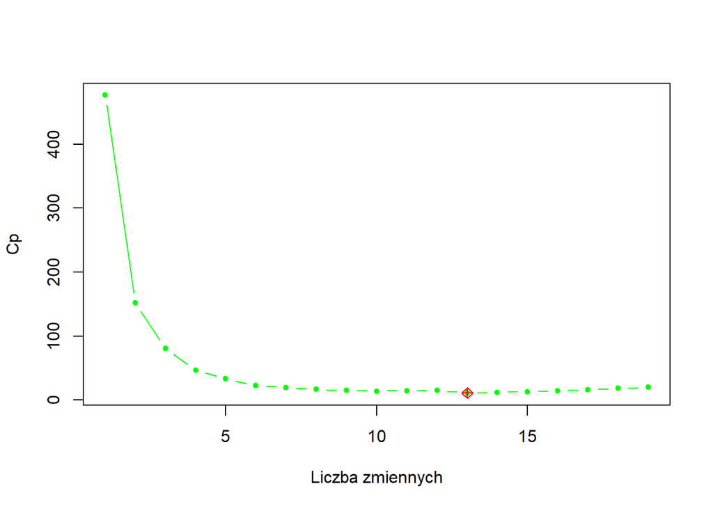

```r
plot(selection_fwd$cp, xlab = "Liczba zmiennych", ylab = "Cp", col = "green",
     type = "b", pch = 20)
points(selection_fwd$cpmin, selection_fwd$cp[selection_fwd$cpmin], col = "red", pch = 9)
```

- kryterium BIC:

```r
selection_fwd$bic
```

```
##  [1] -363.2469 -542.4766 -593.6701 -619.4643 -627.9420 -633.8535 -633.0062
##  [8] -631.9058 -629.7411 -626.8656 -622.4873 -617.6199 -618.3238 -613.2426
## [15] -608.3876 -603.1238 -597.2540 -591.3731 -585.4208
```

```r
selection_fwd$bicmin <- which.min(selection_fwd$bic)
selection_fwd$bicmin
```

```
## [1] 6
```

```r
selection_fwd$bic[selection_fwd$bicmin]
```

```
## [1] -633.8535
```

Według kryterium BIC, najlepszy wynik osiągnął podzbiór 6, w którym wykorzystano 6 cech.

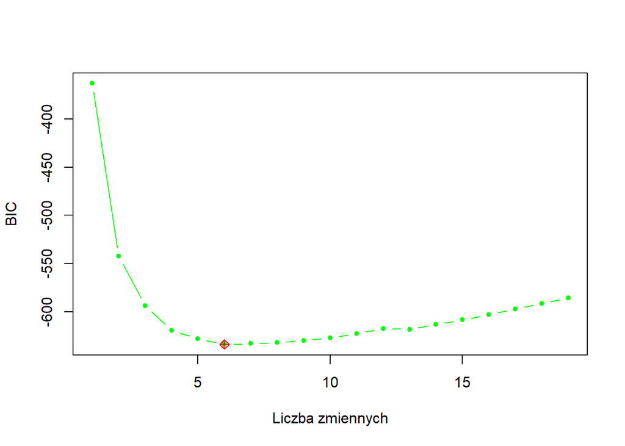

```r
plot(selection_fwd$bic, xlab = "Liczba zmiennych", ylab = "BIC", col = "green",
     type = "b", pch = 20)
points(selection_fwd$bicmin, selection_fwd$bic[selection_fwd$bicmin], col = "red", pch = 9)
```

- poprawione R^2:

```r
selection_fwd$adjr2
```

```
##  [1] 0.6197101 0.7637212 0.7956283 0.8112343 0.8176687 0.8227109 0.8245753
##  [8] 0.8263053 0.8275435 0.8284568 0.8287003 0.8287258 0.8311977 0.8311272
## [15] 0.8311541 0.8310014 0.8305822 0.8301558 0.8296958
```

```r
selection_fwd$adjr2min <- which.max(selection_fwd$adjr2)
selection_fwd$adjr2min
```

```
## [1] 13
```

```r
selection_fwd$adjr2[selection_fwd$adjr2min]
```

```
## [1] 0.8311977
```

Największą wartość poprawionego R^2 uzyskał podzbiór 13 zawierający 13 cech.

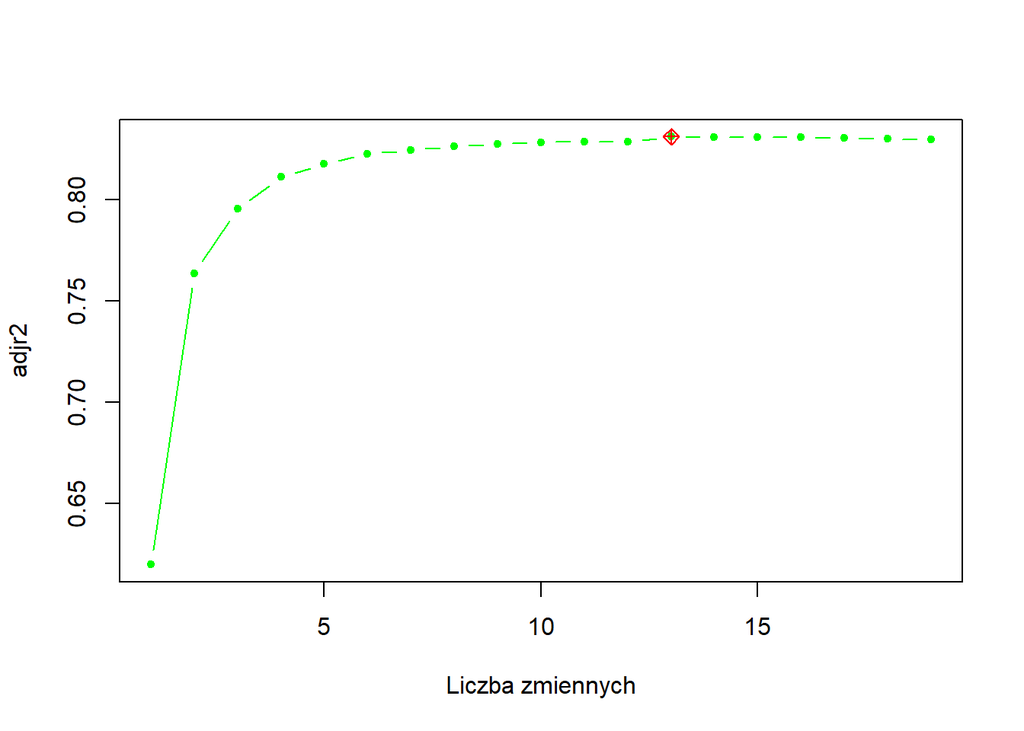

```r
plot(selection_fwd$adjr2, xlab = "Liczba zmiennych", ylab = "adjr2", col = "green",
     type = "b", pch = 20)
points(selection_fwd$adjr2min, selection_fwd$adjr2[selection_fwd$adjr2min], col = "red", pch = 9)
```

### Selekcja krokowa wstecz

```r
selection_bwd <- regsubsets(Life.expectancy ~. -age_group, data = newdata, nvmax = 19, method = "backward")
selection_bwd <- summary(selection_bwd)
selection_bwd
```

```
## Subset selection object
## Call: regsubsets.formula(Life.expectancy ~ . - age_group, data = newdata,
##     nvmax = 19, method = "backward")
## 19 Variables  (and intercept)
##                                 Forced in Forced out
## StatusDeveloping                    FALSE      FALSE
## Adult.Mortality                     FALSE      FALSE
## infant.deaths                       FALSE      FALSE
## Alcohol                             FALSE      FALSE
## percentage.expenditure              FALSE      FALSE
## Hepatitis.B                         FALSE      FALSE
## Measles                             FALSE      FALSE
## BMI                                 FALSE      FALSE
## under.five.deaths                   FALSE      FALSE
## Polio                               FALSE      FALSE
```

[output cut: 111 more lines]

Sprawdżmy, które podzbiory są najlepsze według różnych kryteriów:

- miara Cp:

```r
selection_bwd$cp
```

```
##  [1] 476.706251 151.758638  80.614899  46.409952  32.906616  30.396575
##  [7]  20.717698  10.881477   8.972141   8.979165   8.687554   9.425396
## [13]  10.537425  11.475996  12.792079  14.163457  16.079346  18.005851
## [19]  20.000000
```

```r
selection_bwd$cpmin <- which.min(selection_bwd$cp)
selection_bwd$cpmin
```

```
## [1] 11
```

```r
selection_bwd$cp[selection_bwd$cpmin]
```

```
## [1] 8.687554
```

Według miary Cp najlepszym podzbiorem jest zbiór 11, gdzie użyte zostało 11 cech.

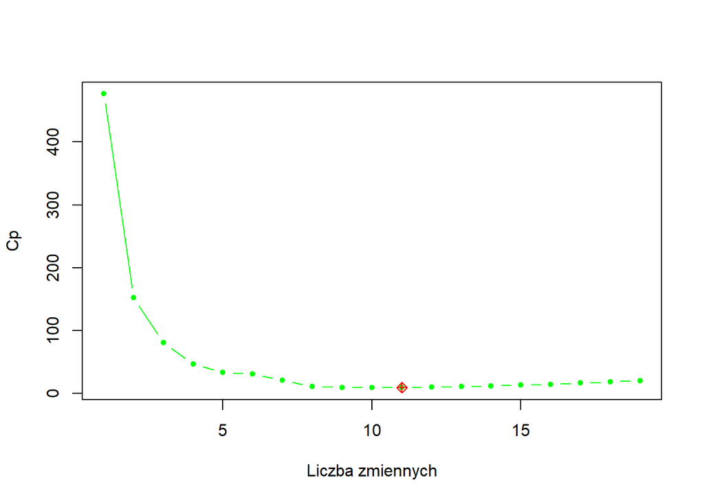

```r
plot(selection_bwd$cp, xlab = "Liczba zmiennych", ylab = "Cp", col = "green",
     type = "b", pch = 20)
points(selection_bwd$cpmin, selection_bwd$cp[selection_bwd$cpmin], col = "red", pch = 9)
```

- kryterium BIC:

```r
selection_bwd$bic
```

```
##  [1] -363.2469 -542.4766 -593.6701 -619.4643 -627.9420 -626.2863 -631.6974
##  [8] -637.6130 -635.6578 -631.7563 -628.1765 -623.5345 -618.5049 -613.6596
## [15] -608.4202 -603.1238 -597.2540 -591.3731 -585.4208
```

```r
selection_bwd$bicmin <- which.min(selection_bwd$bic)
selection_bwd$bicmin
```

```
## [1] 8
```

```r
selection_bwd$bic[selection_bwd$bicmin]
```

```
## [1] -637.613
```

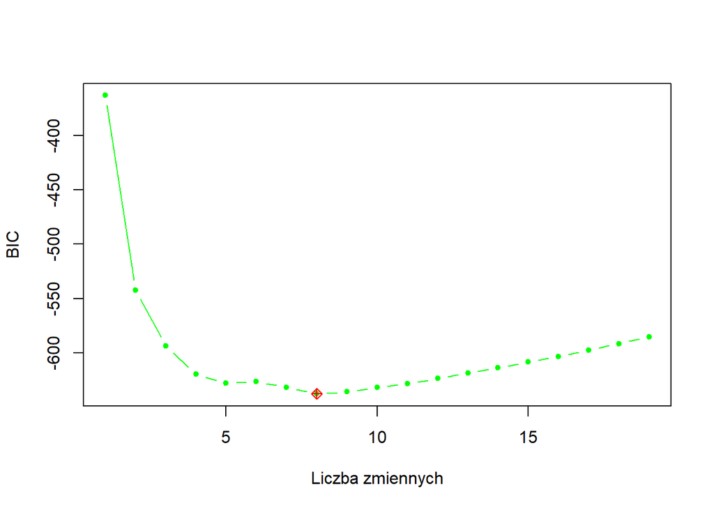

```r
plot(selection_bwd$bic, xlab = "Liczba zmiennych", ylab = "BIC", col = "green",
     type = "b", pch = 20)
points(selection_bwd$bicmin, selection_bwd$bic[selection_bwd$bicmin], col = "red", pch = 9)
```

- poprawione R^2:

```r
selection_bwd$adjr2
```

```
##  [1] 0.6197101 0.7637212 0.7956283 0.8112343 0.8176687 0.8192101 0.8239810
##  [8] 0.8288481 0.8301601 0.8306111 0.8312001 0.8313235 0.8312767 0.8313091
## [15] 0.8311683 0.8310014 0.8305822 0.8301558 0.8296958
```

```r
selection_bwd$adjr2min <- which.max(selection_bwd$adjr2)
selection_bwd$adjr2min
```

```
## [1] 12
```

```r
selection_bwd$adjr2[selection_bwd$adjr2min]
```

```
## [1] 0.8313235
```

Największą wartość poprawionego R^2 uzyskał podzbiór 12 zawierający 12 cech.

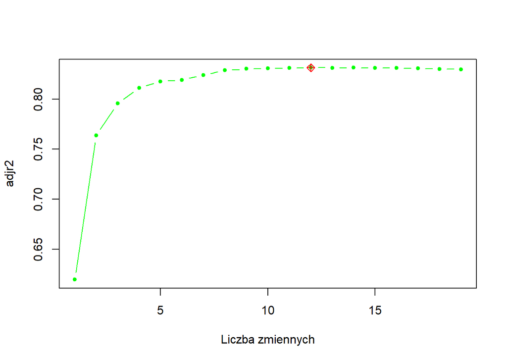

```r
plot(selection_bwd$adjr2, xlab = "Liczba zmiennych", ylab = "adjr2", col = "green",
     type = "b", pch = 20)
points(selection_bwd$adjr2min, selection_bwd$adjr2[selection_bwd$adjr2min], col = "red", pch = 9)
```

Według metody exhaustive oraz selekcji wstecz najlepsze możliwe modele się pokrywały. Model selekcji do przodu wskazał podzbiór 13 dwukrotnie jako najlepszy.

### Wybór modelu przy pomocy metody zbioru walidacyjnego

Podział danych na zbiór uczący i testowy, przeprowadzenie selekcji na zbiorze uczącym:

```r
n <- nrow(newdata)
train <- sample(c(TRUE, FALSE), n, replace = TRUE)
test <- !train
selection_v <- regsubsets(Life.expectancy ~ . -age_group, data = newdata[train,], nvmax = 19)
summary(selection_v)
```

```
## Subset selection object
## Call: regsubsets.formula(Life.expectancy ~ . - age_group, data = newdata[train,
##     ], nvmax = 19)
## 19 Variables  (and intercept)
##                                 Forced in Forced out
## StatusDeveloping                    FALSE      FALSE
## Adult.Mortality                     FALSE      FALSE
## infant.deaths                       FALSE      FALSE
## Alcohol                             FALSE      FALSE
## percentage.expenditure              FALSE      FALSE
## Hepatitis.B                         FALSE      FALSE
## Measles                             FALSE      FALSE
## BMI                                 FALSE      FALSE
## under.five.deaths                   FALSE      FALSE
## Polio                               FALSE      FALSE
```

[output cut: 111 more lines]

Tworzenie funkcji predict:

```r
predict.regsubsets <- function(object, newdata, id, ...) {
  model_formula <- as.formula(object$call[[2]])
  mat <- model.matrix(model_formula, newdata)
  coefs <- coef(object, id = id)
  mat[, names(coefs)] %*% coefs
}
```

Błędy predykcji dla zbioru testowego:

```r
prediction_error <- function(i, model, subset) {
  pred <- predict(model, newdata[subset,], id = i)
  mean((newdata$Life.expectancy[subset] - pred)^2)
}
selection_v$val_errors <- sapply(1:19, prediction_error, model = selection_v, subset = test)
selection_v$val_errors
```

```
##  [1] 30.51215 18.81001 17.18876 15.52385 16.05775 15.41743 14.71935 15.01411
##  [9] 14.22506 14.33063 14.07001 13.93515 13.89833 14.00235 13.97695 14.13763
## [17] 14.14721 14.14106 14.14188
```

```r
selection_v$best <- which.min(selection_v$val_errors)
```

Według analizy przy pomocy metody zbioru walidacyjnego najlepszym modelem jest model:

```r
selection_v$best
```

```
## [1] 13
```

### Wybór modelu przy pomocy k-krotnej walidacji krzyżowej

```r
k <- 10
folds <- sample(1:k, n, replace = TRUE)
val_err <- NULL
for (j in 1:k) {
  selection_cross <- regsubsets(Life.expectancy ~ . -age_group, data = newdata[folds != j,], nvmax = 19)
  selection_cross$err <- sapply(1:19, prediction_error, model = selection_cross, subset = (folds == j))
  val_err <- rbind(val_err, selection_cross$err)
}
```

Wyznaczenie wartości błędów:

```r
selection_cross$cv_errors <- colMeans(val_err)
selection_cross$cv_errors
```

```
##  [1] 31.28966 19.58796 17.12542 15.82021 15.65169 15.51261 15.55736 14.49116
##  [9] 14.51217 14.71375 14.54634 14.66355 14.69797 14.71146 14.70765 14.64608
## [17] 14.69578 14.68868 14.69155
```

```r
selection_cross$best <- which.min(selection_cross$cv_errors)
```

Analiza modeli przy pomocy k-krotnej walidacji krzyżowej wskazuje, że najlepszym modelem jest model:

```r
selection_cross$best
```

```
## [1] 8
```

### Porównanie wyników metod selekcji cech

```r
selection_tab <- matrix(c(selection$cpmin, selection$bicmin, selection$adjr2min, selection_fwd$cpmin, selection_fwd$bicmin, selection_fwd$adjr2min, selection_bwd$cpmin, selection_bwd$bicmin, selection_bwd$adjr2min, selection_v$best, selection_cross$best), nrow=11,ncol=1)
colnames(selection_tab) <- c("Ilość predyktorów")
rownames(selection_tab) <- c('Selekcja Cp', 'Selekcja BIC', 'Selekcja adjr2', 'Selekcja forward Cp', 'Selekcja forward BIC', 'Selekcja forward adjr2', 'Selekcja backward Cp', 'Selekcja backward BIC', 'Selekcja backward adjr2', 'Model walidacyjny', 'k-krotna walidacja krzyżowa')

selection_tab <- as.table(selection_tab)
selection_tab
```

```
##                             Ilość predyktorów
## Selekcja Cp                                11
## Selekcja BIC                                8
## Selekcja adjr2                             12
## Selekcja forward Cp                        13
## Selekcja forward BIC                        6
## Selekcja forward adjr2                     13
## Selekcja backward Cp                       11
## Selekcja backward BIC                       8
## Selekcja backward adjr2                    12
## Model walidacyjny                          13
## k-krotna walidacja krzyżowa                 8
```

## Regularyzacja metodą lasso

### Dla regresji

W celu dokonania regularyzacji metodą lasso należy stworzyć macierz X. Macierz X zostaje podzielona na dwa podzbiory: uczący i testowy. Dane powinny zostać wystandaryzowane.

```r
lasso <-list()
lasso$X <- model.matrix(Life.expectancy ~ .-(age_group + Status), data = newdata)[, -1]
lasso$y <- newdata$Life.expectancy
lasso$X <- scale(lasso$X)
lasso$y <- scale(lasso$y)
set.seed(1)
n <- nrow(lasso$X)
lasso$train <- sample(n, n / 2)
lasso$test <- -lasso$train
```

Dopasowanie lasso dla ustalonej siatki parametrów regularyzacji:

```r
library(glmnet)
```

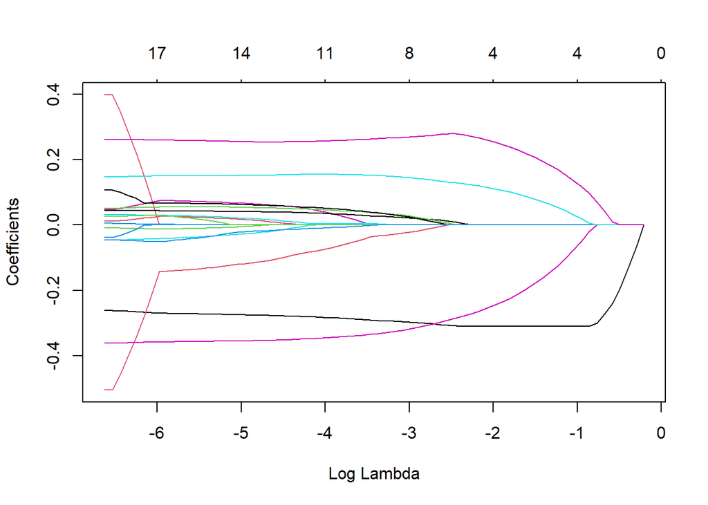

```r
lasso$model <- glmnet(lasso$X[lasso$train,], lasso$y[lasso$train], alpha = 1)
plot(lasso$model, xvar = "lambda")
```

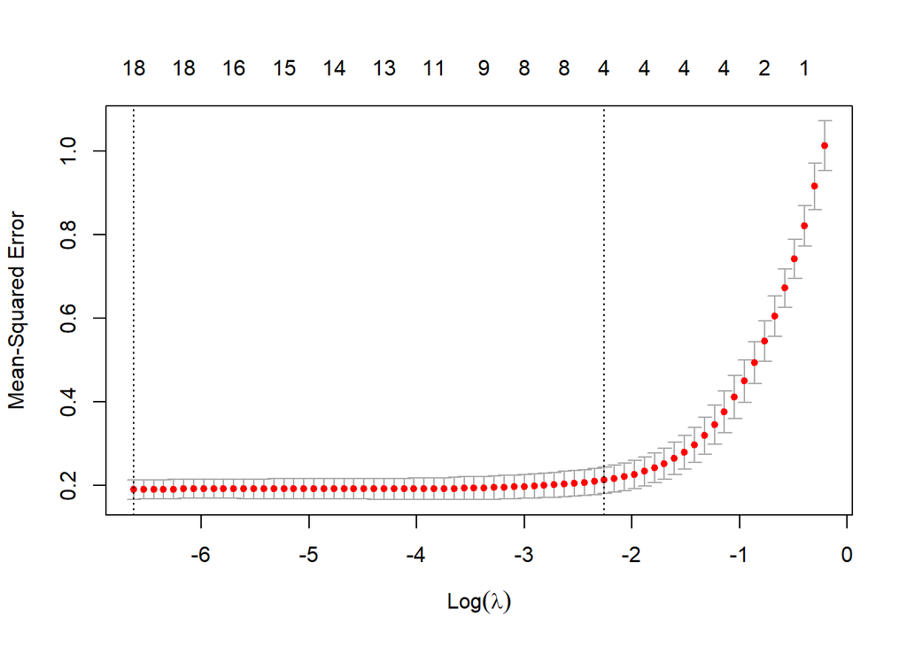

```r
lasso$cv_out <- cv.glmnet(lasso$X[lasso$train,], lasso$y[lasso$train], alpha = 1)
plot(lasso$cv_out)
```

```r
lasso$cv_out$lambda.min
```

```
## [1] 0.00132036
```

```r
lasso$pred <- predict(lasso$model, s = lasso$cv_out$lambda.min, newx = lasso$X[lasso$test,])
```

```r
mean((lasso$pred - lasso$y[lasso$test])^2)
```

```
## [1] 0.2013511
```

Lasso dopasowane na zbiorze dla optymalnej wartości lambda daje powyższą wartość MSE.

```r
lasso$model_full <- glmnet(lasso$X, lasso$y, alpha = 1)
predict(lasso$model_full, s = lasso$cv_out$lambda.min, type = "coefficients")[2:19,]
```

```
##                 Adult.Mortality                   infant.deaths
##                    -0.317375437                     0.229659563
##                         Alcohol          percentage.expenditure
##                    -0.056470119                    -0.023186342
##                     Hepatitis.B                         Measles
##                    -0.028526827                     0.036160914
##                             BMI               under.five.deaths
##                     0.057763768                    -0.254154539
##                           Polio               Total.expenditure
##                     0.039371335                    -0.003941420
##                      Diphtheria                        HIV.AIDS
##                     0.029527021                    -0.241075363
##                             GDP                      Population
##                     0.121670501                     0.002705909
##            thinness..1.19.years              thinness.5.9.years
##                     0.000000000                    -0.076389463
## Income.composition.of.resources                       Schooling
##                     0.164563089                     0.297043422
```

Dzięki uzyskanym współczynnikom dla optymalnego lambda wiadomo, że predyktor: thinness..1.19.years zostały wykluczone (nie powinien być uwzględniony w modelu).

```r
which.max(predict(lasso$model_full, s = lasso$cv_out$lambda.min, type = "coefficients")[2:19,])
```

```
## Schooling
##        18
```

```r
which.min(predict(lasso$model_full, s = lasso$cv_out$lambda.min, type = "coefficients")[2:19,])
```

```
## Adult.Mortality
##               1
```

Jednocześnie widać, że predyktorem o największym współczynniku jest Schooling (największa wartość dodatniego współczynnika - korelacja dodatnia z Life.expectancy).

Z kolei najniższy wpółczynnik uzyskał Adult.Mortality (największa wartość ujemnego współczynnika - korelacja ujemna z Life.expectancy).

## Drzewa decyzyjne

Dla zadań klasyfikacji obserwacje zostaną sklasyfikowane do dwóch klas na podstawie długowieczności. Jeśli przewidywany wiek mieścił się w przedziałach 35 - 65 - klasa 0, a 65 - 80+ 1.

```r
Long <- factor(ifelse(newdata$Life.expectancy < 65, 0, 1))
newdataDecision <- data.frame(newdata, Long)
```

Zbiory uczący oraz testowy dla zadania klasyfikacji:

```r
set.seed(1)
n <- nrow(newdataDecision)
class_train <- sample(n, n / 2)
class_test <- -class_train
```

Zbiory uczący oraz testowy dla zadania regresji:

```r
set.seed(1)
n <- nrow(newdata)
reg_train <- sample(n, n / 2)
reg_test <- -reg_train
```

### Dla klasyfikacji

```r
library(tree)
tree_model <- tree(Long ~ . - (Life.expectancy + age_group), data = newdataDecision)
summary(tree_model)
```

```
##
## Classification tree:
## tree(formula = Long ~ . - (Life.expectancy + age_group), data = newdataDecision)
## Variables actually used in tree construction:
## [1] "Adult.Mortality"                 "HIV.AIDS"
## [3] "Schooling"                       "Income.composition.of.resources"
## [5] "Total.expenditure"               "infant.deaths"
## [7] "Population"
## Number of terminal nodes:  12
## Residual mean deviance:  0.0805 = 30.19 / 375
## Misclassification error rate: 0.01809 = 7 / 387
```

Jak widać w modelu użyto rzeczywiście 7 cech.

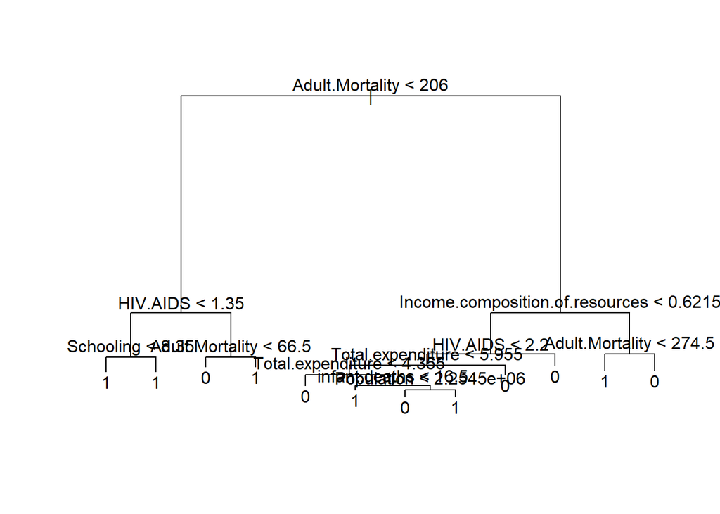

```r
plot(tree_model)
text(tree_model, pretty = 0)
```

```r
print(tree_model)
```

```
## node), split, n, deviance, yval, (yprob)
##       * denotes terminal node
##
##   1) root 387 474.300 1 ( 0.302326 0.697674 )
##     2) Adult.Mortality < 206 254  90.580 1 ( 0.043307 0.956693 )
##       4) HIV.AIDS < 1.35 241  23.150 1 ( 0.008299 0.991701 )
##         8) Schooling < 8.35 5   6.730 1 ( 0.400000 0.600000 ) *
##         9) Schooling > 8.35 236   0.000 1 ( 0.000000 1.000000 ) *
##       5) HIV.AIDS > 1.35 13  16.050 0 ( 0.692308 0.307692 )
##        10) Adult.Mortality < 66.5 8   0.000 0 ( 1.000000 0.000000 ) *
##        11) Adult.Mortality > 66.5 5   5.004 1 ( 0.200000 0.800000 ) *
##     3) Adult.Mortality > 206 133 134.200 0 ( 0.796992 0.203008 )
##       6) Income.composition.of.resources < 0.6215 110  62.300 0 ( 0.918182 0.081818 )
##        12) HIV.AIDS < 2.2 56  49.380 0 ( 0.839286 0.160714 )
##          24) Total.expenditure < 5.955 33  38.670 0 ( 0.727273 0.272727 )
##            48) Total.expenditure < 4.355 14   0.000 0 ( 1.000000 0.000000 ) *
##            49) Total.expenditure > 4.355 19  26.290 0 ( 0.526316 0.473684 )
##              98) infant.deaths < 16.5 6   5.407 1 ( 0.166667 0.833333 ) *
##              99) infant.deaths > 16.5 13  16.050 0 ( 0.692308 0.307692 )
##               198) Population < 2.2545e+06 7   0.000 0 ( 1.000000 0.000000 ) *
##               199) Population > 2.2545e+06 6   7.638 1 ( 0.333333 0.666667 ) *
##          25) Total.expenditure > 5.955 23   0.000 0 ( 1.000000 0.000000 ) *
##        13) HIV.AIDS > 2.2 54   0.000 0 ( 1.000000 0.000000 ) *
##       7) Income.composition.of.resources > 0.6215 23  24.080 1 ( 0.217391 0.782609 )
##        14) Adult.Mortality < 274.5 17   0.000 1 ( 0.000000 1.000000 ) *
##        15) Adult.Mortality > 274.5 6   5.407 0 ( 0.833333 0.166667 ) *
```

Na podstawie wykresu drzewka decyzyjnego można stwierdzić, że jedną z najważniejszych cech przy podziale gałęzi był Adult.Mortality (pojawia się wielokrotnie oraz na początku drzewa), a także Total.expenditure oraz HIV.AIDS.

Metoda zbioru walidacyjnego pozwala oszacować błąd na poziomie:

```r
set.seed(1)
tree_model <- tree(Long ~ . -(Life.expectancy + age_group), data = newdataDecision, subset = class_train)
tree_class <- predict(tree_model, newdata = newdataDecision[class_test,], type = "class")
table(tree_class, Long[class_test])
```

```
##
## tree_class   0   1
##          0  46   8
##          1  12 128
```

```r
tree_1 <- mean(tree_class != Long[class_test])
tree_1
```

```
## [1] 0.1030928
```

Poniżej przedstawiono wizualizację drzewa:

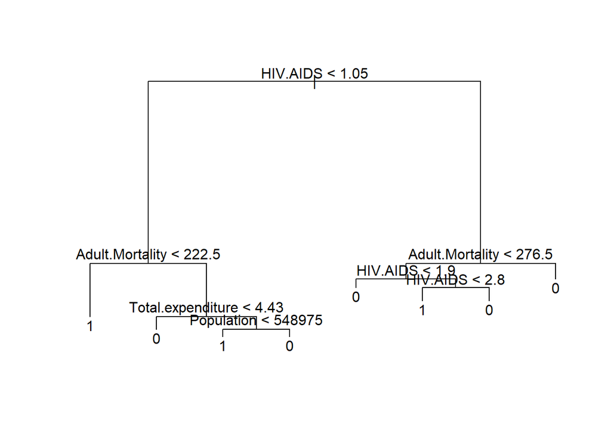

```r
plot(tree_model)
text(tree_model, pretty = 0)
```

Następnie skonstruowano ciąg poddrzew w celu sprawdzenia, jak bardzo złożone powinno być drzewo:

```r
set.seed(1)
tree_cv <- cv.tree(tree_model, FUN = prune.misclass)
tree_cv
```

```
## $size
## [1] 8 7 4 2 1
##
## $dev
## [1] 27 27 21 21 59
##
## $k
## [1]      -Inf  0.000000  1.333333  2.500000 45.000000
##
## $method
## [1] "misclass"
##
## attr(,"class")
## [1] "prune"         "tree.sequence"
```

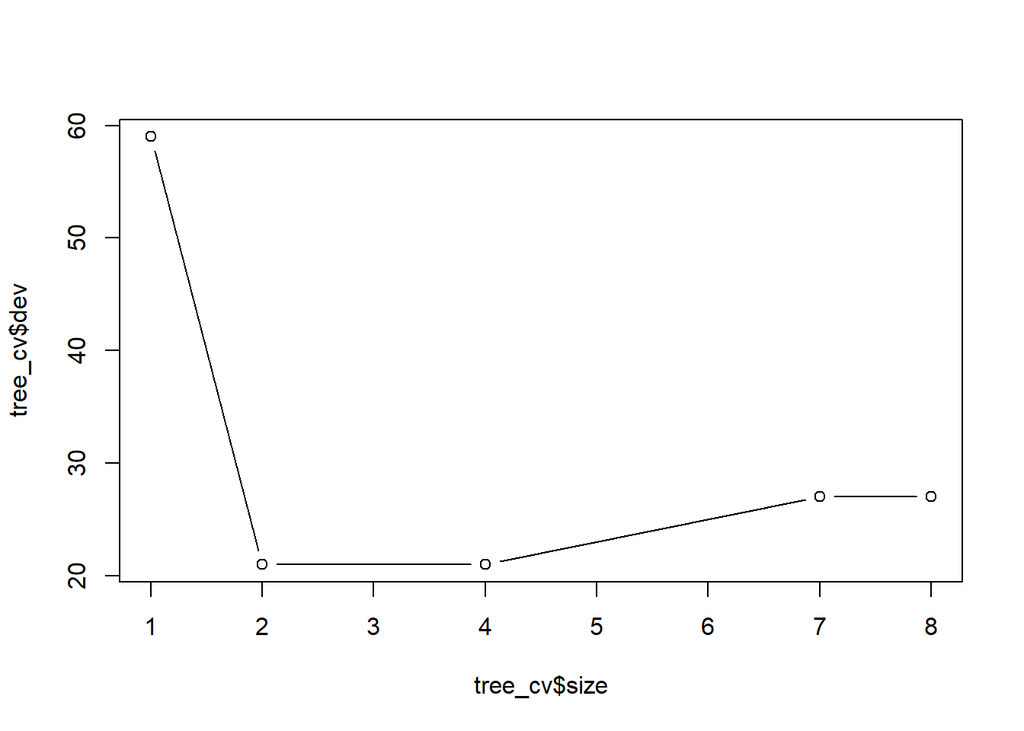

```r
plot(tree_cv$size, tree_cv$dev, type = "b")
```

Z wykresu wnioskujemy, że najlepszy wynik osiąga drzewo posiadające 4 liście.

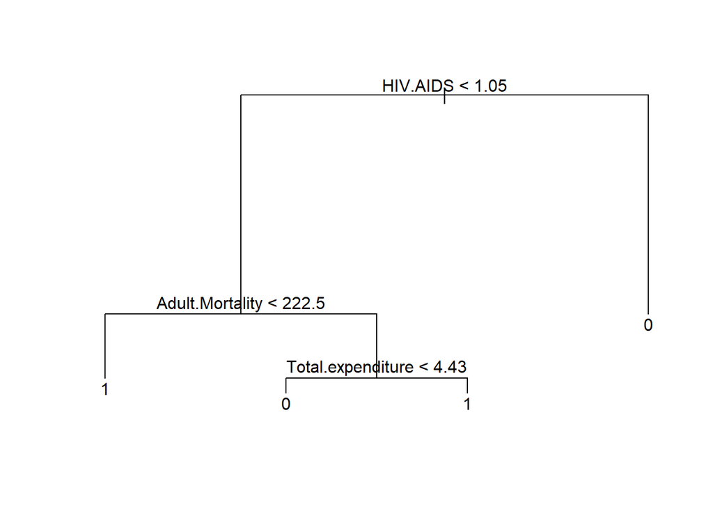

```r
size_opt <- tree_cv$size[which.min(tree_cv$dev)]
tree_pruned <- prune.misclass(tree_model, best = size_opt)
plot(tree_pruned)
text(tree_pruned, pretty = 0)
```

Drzewo o złożoności 4 liści osiągnęło błąd:

```r
set.seed(1)
pruned_class <- predict(tree_pruned, newdata = newdataDecision[class_test,],
                        type = "class")
table(pruned_class, newdataDecision$Long[class_test])
```

```
##
## pruned_class   0   1
##            0  42   8
##            1  16 128
```

```r
tree_2 <- mean(pruned_class != newdataDecision$Long[class_test])
tree_2
```

```
## [1] 0.1237113
```

czyli delikatnie większy błąd niż początkowe drzewo.

### Dla Regresji

```r
tree_model2 <- tree(Life.expectancy ~ . -(age_group), data = newdata)
summary(tree_model2)
```

```
##
## Regression tree:
## tree(formula = Life.expectancy ~ . - (age_group), data = newdata)
## Variables actually used in tree construction:
## [1] "Adult.Mortality"                 "Income.composition.of.resources"
## [3] "HIV.AIDS"                        "thinness..1.19.years"
## Number of terminal nodes:  8
## Residual mean deviance:  10.03 = 3803 / 379
## Distribution of residuals:
##      Min.   1st Qu.    Median      Mean   3rd Qu.      Max.
## -11.05000  -1.90400  -0.07222   0.00000   2.06400   8.84600
```

W modelu użyto rzeczywiście 4 cechy.

```r
tree_model2
```

```
## node), split, n, deviance, yval
##       * denotes terminal node
##
##  1) root 387 30840.00 68.47
##    2) Adult.Mortality < 206 254  8287.00 73.29
##      4) Income.composition.of.resources < 0.786 187  4334.00 71.22
##        8) HIV.AIDS < 2.55 181  2302.00 71.79
##         16) Income.composition.of.resources < 0.632 67   930.70 69.15 *
##         17) Income.composition.of.resources > 0.632 114   632.70 73.34 *
##        9) HIV.AIDS > 2.55 6   184.50 53.95 *
##      5) Income.composition.of.resources > 0.786 67   888.00 79.10
##       10) thinness..1.19.years < 1.75 54   384.70 80.40 *
##       11) thinness..1.19.years > 1.75 13    29.14 73.68 *
##    3) Adult.Mortality > 206 133  5374.00 59.27
##      6) Adult.Mortality < 347.5 93  1561.00 62.45
##       12) Adult.Mortality < 277.5 57   554.70 64.46 *
##       13) Adult.Mortality > 277.5 36   411.60 59.27 *
##      7) Adult.Mortality > 347.5 40   674.50 51.86 *
```

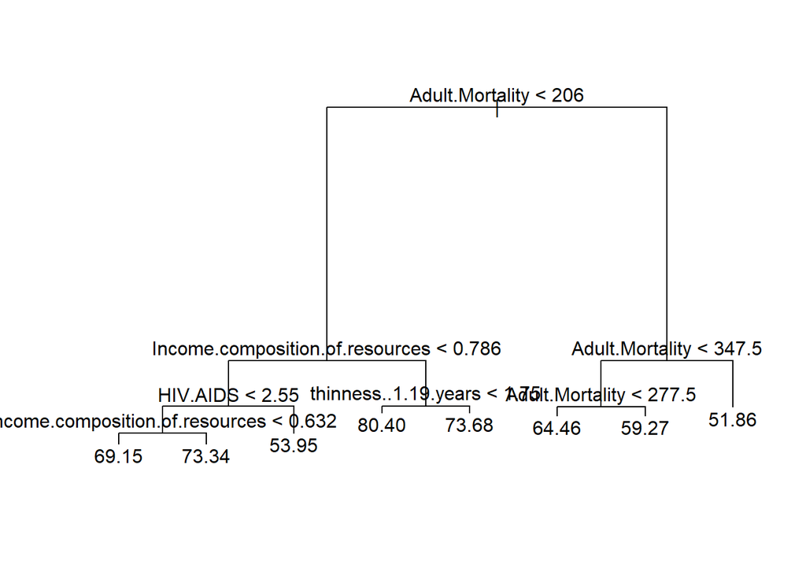

```r
plot(tree_model2)
text(tree_model2)
```

Dzięki wykresowi drzewka decyzyjnego, można wnioskować, że najważniejszymi predyktorami były Adult.Mortality oraz Income.composition.of.resources.

```r
set.seed(1)
tree_model2 <- tree(Life.expectancy ~ ., data = newdata, subset = reg_train)
tree_pred2 <- predict(tree_model2, newdata = newdata[reg_test,])
tree_3 <-mean((tree_pred2 - newdata$Life.expectancy[reg_test])^2)
tree_3
```

```
## [1] 16.73669
```

Zastosowanie metody zbioruwalidacyjnego dało wynik błędu testowego 16.74.

Aby ustalić optymalny rozmiar drzewa sprawdzamy ciąg poddrzew metodą sterowaną złożonością.

```r
set.seed(1)
tree_cv2 <- cv.tree(tree_model2)
```

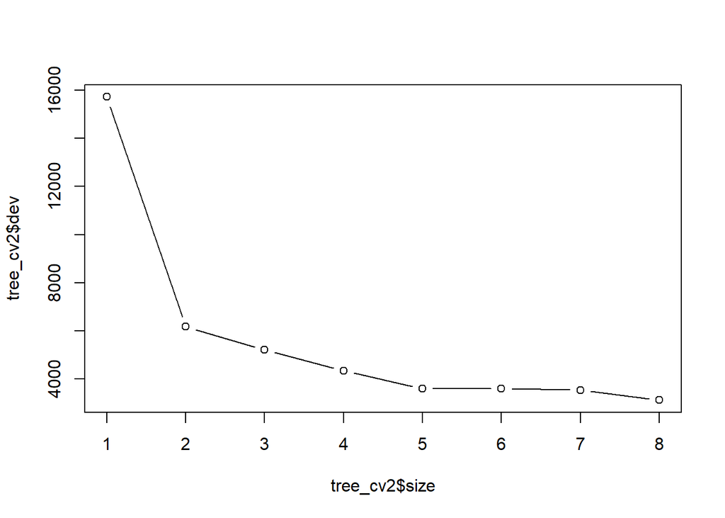

```r
plot(tree_cv2$size, tree_cv2$dev, type = "b")
```

```r
size_opt <- tree_cv2$size[which.min(tree_cv2$dev)]
size_opt
```

```
## [1] 8
```

Optymalnym rozmiarem drzewa wydaje się być 8 liści. Poniżej przedstawiono wykres optymalnego drzewa.

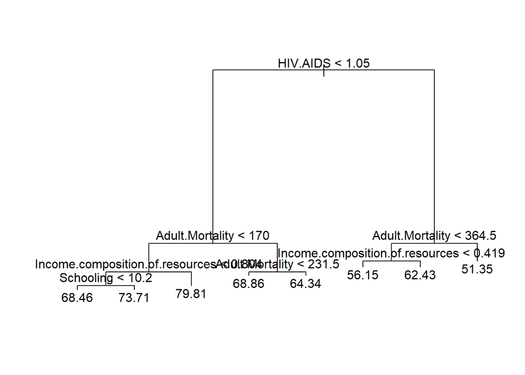

```r
set.seed(1)
tree_pruned2 <- prune.tree(tree_model2, best = size_opt)
plot(tree_pruned2)
text(tree_pruned2)
```

Dla optymalnego drzewa błąd testowy osiągnał wartość:

```r
tree_pred2 <- predict(tree_pruned2, newdata = newdata[reg_test,])
tree_4 <-mean((tree_pred2 - newdata$Life.expectancy[reg_test])^2)
tree_4
```

```
## [1] 16.73669
```

## Lasy losowe

### Dla klasyfikacji

Parametr mtry ustawiono na p/3, gdzie p = 19.

```r
library(randomForest)
set.seed(1)
p <- 19
forest <- randomForest(Long ~ . -(Life.expectancy +age_group), data = newdataDecision, subset = class_train, mtry = p/3, importance = TRUE)
```

Wartość błędu predykcji wynosi:

```r
forest_class <- predict(forest, newdata = newdataDecision[class_test,], type = "class")
table(forest_class, Long[class_test])
```

```
##
## forest_class   0   1
##            0  46   1
##            1  12 135
```

```r
forest_1 <-mean(forest_class != Long[class_test])
forest_1
```

```
## [1] 0.06701031
```

### Dla regresji

Parametr mtry ustawiono na sqrt(p), gdzie p = 19.

```r
set.seed(1)
p <- 19
forest2 <- randomForest(Life.expectancy ~ . -Life.expectancy, data = newdata, subset = reg_train, mtry = sqrt(p), importance = TRUE )
```

Powyższy model dał wynik błędu:

```r
forest_pred <- predict(forest2, newdata = newdata[reg_test,])
forest_2 <- mean((forest_pred - newdata$Life.expectancy[reg_test])^2)
forest_2
```

```
## [1] 5.955499
```

## Boosting

### Dla klasyfikacji

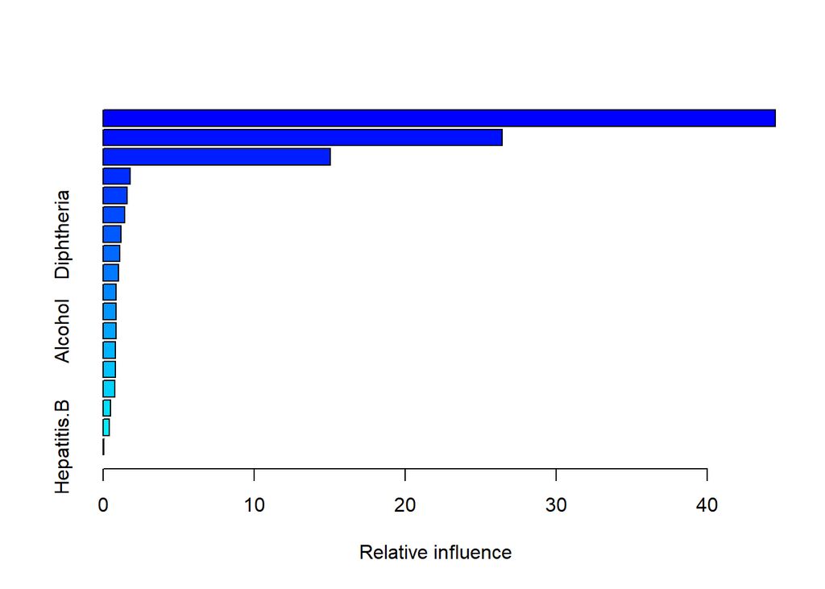

```
##                                                             var     rel.inf
## Adult.Mortality                                 Adult.Mortality 44.48999360
## HIV.AIDS                                               HIV.AIDS 26.42419761
## Income.composition.of.resources Income.composition.of.resources 15.05723623
## Total.expenditure                             Total.expenditure  1.78415073
## Schooling                                             Schooling  1.56985989
## GDP                                                         GDP  1.43530367
## Diphtheria                                           Diphtheria  1.18239962
## thinness.5.9.years                           thinness.5.9.years  1.10657397
## Polio                                                     Polio  1.01589847
## thinness..1.19.years                       thinness..1.19.years  0.86496261
## Population                                           Population  0.86381326
## Alcohol                                                 Alcohol  0.86218358
## infant.deaths                                     infant.deaths  0.83503690
## percentage.expenditure                   percentage.expenditure  0.83182692
## BMI                                                         BMI  0.75729500
## under.five.deaths                             under.five.deaths  0.47318581
## Measles                                                 Measles  0.40685112
## Hepatitis.B                                         Hepatitis.B  0.03923103
```

```r
library(gbm)
boost <- gbm(I(Long == 1) ~ . - (Life.expectancy + age_group + Status), data = newdataDecision, distribution = 'bernoulli', n.trees = 5000, interaction.depth = 4)
summary(boost)
```

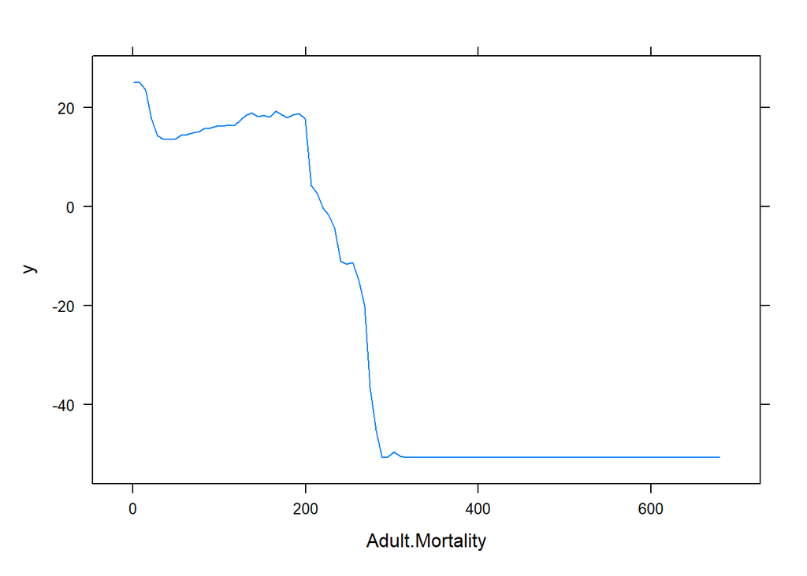

```r
plot(boost, i.var = "Adult.Mortality")
```